# Linear Mixed Effects Models

Joe Celebrezze

2023-06-28

# Questions

- How to deal with plant traits variables which are only measured per plant_id?
- REML = FALSE? Based on what I know, REML should = TRUE if you’re mostly concerned with variance and covariance, so maybe it makes sense to keep it like this when evaluating VIF scores, but when doing AIC-based model selection, it might make more sense to do REML = FALSE (this is how I have it now, based on recent changes)

# Data Structure

For the linear mixed effects models, we are going to be using the *flammability metrics* below as **dependent variables**:

- Flame height (fh)
- Flame duration (fd)
- Change in temp. (temp_change)
- Change in heat flux (heat_flux_change)

The following variables are not going to be considered (with the reasoning behind omitting each one described below):

- Time to ignition (tti): because this variable is conceptually meaningless for all manual ignitions (the majority of ignitions)
- Post-flame glow (pfg): because we do not necessarily trust the glow end time, as it was challenging to see in video playbacks when the sample stopped glowing. Because of this drawback, we relied on the people present during the flammability lab testing to clap at the end of the glow time, but the timing of this clap did not always correspond with the exact end of glowing
- Proportion ignited (prop_ig): because this variable has only one value for each species which does not fit the structure of the models

We have a plethora of variables that could be used as predictors and also a lot of potential covariates. The potential **predictors** are grouped and listed below:

*Species*: This will likely be included in every model, as understanding interspecific differences and grouping species by flammability is our central question

*Hydration or dryness*: - LFM (can be total LFM, leaf LFM and/or stem LFM) - Water potential (mpa) - Wet weight (ww_flam_sample) - Dry weight (dw_flam_sample)

*Leaf morphology*: - LMA or SLA - Leaf area (likely unnecessary, as described by LMA and SLA in some capacity) - Leaf thickness

*Sample morphology*: - Branching - Stem to leaf ratio - Sample weight* (note: this could also be considered a covariate)

Potential **covariates**:

- Starting temperature (start_temp)
- Sample weight* (see note above)
- Sample volume (branch_volume): could also split by height, width and length (although length is mostly the same across samples)
- Ambient humidity or temperature (note: I don’t necessarily trust that the meter was doing a good job gathering this data, as it seems like the temperature of the chamber affected the measurements)
- Thermocoupler and hot plate height: probably not necessary, as exploratory analyses showed that there weren’t any major differences between variables depending on the thermocoupler height or hot plate height

**Random effect**:

- Plant (to account for repeated measurements): note that we will need to make a unique identifier for each plant by combining current columns ‘species’ and ‘plant’. Otherwise, the model will assume that (for example) plant 1 is the same group, treating HETARB 1 and SALLEU 1 as similar when they should not be treated as similar

Looking at the above variables to see how they’re situated in the dataset

```r
# Grouping by plant_id; to check to see which traits do not have any variation per plant_id
trait.summary.plant_id <- flamm.df %>%
  unite('plant_id', c(species, plant), sep = '_', remove = F) %>%
  select(fh, species, lfm, leaf_lfm, stem_lfm, mpa, ww_flam_sample, dw_flam_sample, LMA, SLA, thickness, leaf_area, branching, stem_mass_ratio, leaf_mass_ratio, sample_wt, start_temp, branch_volume, ambient_humidity, ambient_temp, thermocoupler_height, hotplate_height, plant_id) %>%
  mutate(lfm = scale(lfm), mpa = scale(mpa), ww_flam_sample = scale(ww_flam_sample),
         dw_flam_sample = scale(dw_flam_sample), LMA = scale(LMA), thickness = scale(thickness),
         leaf_area = scale(leaf_area), branching = scale(branching),
         leaf_mass_ratio = scale(leaf_mass_ratio), sample_wt = scale(sample_wt),
         start_temp = scale(start_temp), branch_volume = scale(branch_volume)) %>%  # scaling traits we want to look at so that standard deviations are comparable
  group_by(plant_id) %>%
  dplyr::summarise(sd_lfm = sd(lfm), sd_mpa = sd(mpa), sd_ww = sd(ww_flam_sample), sd_dw = sd(dw_flam_sample),
                   sd_lma = sd(LMA), sd_thickness = sd(thickness), sd_leafarea = sd(leaf_area),
                   sd_branching = sd(branching), sd_leafratio = sd(leaf_mass_ratio), sd_sw = sd(sample_wt),
                   sd_st = sd(start_temp), sd_volume = sd(branch_volume))
trait.summary.plant_id %>%
  mutate(sd_lfm = ifelse(is.na(sd_lfm), 0, sd_lfm),
         sd_mpa = ifelse(is.na(sd_mpa), 0, sd_mpa),
         sd_ww = ifelse(is.na(sd_ww), 0, sd_ww),
         sd_dw = ifelse(is.na(sd_dw), 0, sd_dw),
         sd_lma = ifelse(is.na(sd_lma), 0, sd_lma),
         sd_thickness = ifelse(is.na(sd_thickness), 0, sd_thickness),
         sd_leafarea = ifelse(is.na(sd_leafarea), 0, sd_leafarea),
         sd_branching = ifelse(is.na(sd_branching), 0, sd_branching),
         sd_leafratio = ifelse(is.na(sd_leafratio), 0, sd_leafratio),
         sd_sw = ifelse(is.na(sd_sw), 0, sd_sw),
         sd_st = ifelse(is.na(sd_st), 0, sd_st),
         sd_volume = ifelse(is.na(sd_volume), 0, sd_volume)) %>%
  summary()
```

```
##    plant_id             sd_lfm      sd_mpa            sd_ww
##  Length:71          Min.   :0   Min.   :0.00000   Min.   :0.00000
##  Class :character   1st Qu.:0   1st Qu.:0.04534   1st Qu.:0.01974
##  Mode  :character   Median :0   Median :0.34408   Median :0.07820
##                     Mean   :0   Mean   :0.39521   Mean   :0.21370
##                     3rd Qu.:0   3rd Qu.:0.56048   3rd Qu.:0.32713
##                     Max.   :0   Max.   :1.63212   Max.   :1.33386
##      sd_dw             sd_lma   sd_thickness  sd_leafarea  sd_branching
##  Min.   :0.00000   Min.   :0   Min.   :0     Min.   :0    Min.   :0.0000
##  1st Qu.:0.01535   1st Qu.:0   1st Qu.:0     1st Qu.:0    1st Qu.:0.0000
##  Median :0.07498   Median :0   Median :0     Median :0    Median :0.1741
##  Mean   :0.20153   Mean   :0   Mean   :0     Mean   :0    Mean   :0.3265
##  3rd Qu.:0.30542   3rd Qu.:0   3rd Qu.:0     3rd Qu.:0    3rd Qu.:0.5999
##  Max.   :1.32151   Max.   :0   Max.   :0     Max.   :0    Max.   :2.1284
##   sd_leafratio     sd_sw             sd_st           sd_volume
##  Min.   :0     Min.   :0.00000   Min.   :0.00000   Min.   :0.000000
##  1st Qu.:0     1st Qu.:0.01857   1st Qu.:0.03136   1st Qu.:0.002173
##  Median :0     Median :0.08104   Median :0.16962   Median :0.100116
##  Mean   :0     Mean   :0.21151   Mean   :0.23917   Mean   :0.258683
##  3rd Qu.:0     3rd Qu.:0.31706   3rd Qu.:0.31998   3rd Qu.:0.378986
##  Max.   :0     Max.   :1.33903   Max.   :2.21121   Max.   :2.032736
```

```r
# Grouping by species; to check to see which traits do not have any intraspecific variation
trait.summary.species <- flamm.df %>%  # scaling so that standard deviations are comparable
  select(fh, species, lfm, leaf_lfm, stem_lfm, mpa, ww_flam_sample, dw_flam_sample, LMA, SLA, thickness, leaf_area, branching, stem_mass_ratio, leaf_mass_ratio, sample_wt, start_temp, branch_volume, ambient_humidity, ambient_temp, thermocoupler_height, hotplate_height) %>%
  mutate(lfm = scale(lfm), mpa = scale(mpa), ww_flam_sample = scale(ww_flam_sample),
         dw_flam_sample = scale(dw_flam_sample), LMA = scale(LMA), thickness = scale(thickness),
         leaf_area = scale(leaf_area), branching = scale(branching),
         leaf_mass_ratio = scale(leaf_mass_ratio), sample_wt = scale(sample_wt),
         start_temp = scale(start_temp), branch_volume = scale(branch_volume)) %>%  # scaling traits we want to look at so that standard deviations are comparable
  group_by(species) %>%
  dplyr::summarise(sd_lfm = sd(lfm), sd_mpa = sd(mpa), sd_ww = sd(ww_flam_sample), sd_dw = sd(dw_flam_sample),
                   sd_lma = sd(LMA), sd_thickness = sd(thickness), sd_leafarea = sd(leaf_area),
                   sd_branching = sd(branching), sd_leafratio = sd(leaf_mass_ratio), sd_sw = sd(sample_wt),
                   sd_st = sd(start_temp), sd_volume = sd(branch_volume))
trait.summary.species %>%
  mutate(sd_lfm = ifelse(is.na(sd_lfm), 0, sd_lfm),
         sd_mpa = ifelse(is.na(sd_mpa), 0, sd_mpa),
         sd_ww = ifelse(is.na(sd_ww), 0, sd_ww),
         sd_dw = ifelse(is.na(sd_dw), 0, sd_dw),
         sd_lma = ifelse(is.na(sd_lma), 0, sd_lma),
         sd_thickness = ifelse(is.na(sd_thickness), 0, sd_thickness),
         sd_leafarea = ifelse(is.na(sd_leafarea), 0, sd_leafarea),
         sd_branching = ifelse(is.na(sd_branching), 0, sd_branching),
         sd_leafratio = ifelse(is.na(sd_leafratio), 0, sd_leafratio),
         sd_sw = ifelse(is.na(sd_sw), 0, sd_sw),
         sd_st = ifelse(is.na(sd_st), 0, sd_st),
         sd_volume = ifelse(is.na(sd_volume), 0, sd_volume)) %>%
  summary()
```

```
##    species              sd_lfm           sd_mpa           sd_ww
##  Length:9           Min.   :0.1347   Min.   :0.3399   Min.   :0.06119
##  Class :character   1st Qu.:0.2596   1st Qu.:0.6033   1st Qu.:0.26102
##  Mode  :character   Median :0.3076   Median :0.6208   Median :0.40833
##                     Mean   :0.3719   Mean   :0.6743   Mean   :0.60361
##                     3rd Qu.:0.3805   3rd Qu.:0.7511   3rd Qu.:1.00952
##                     Max.   :0.8577   Max.   :1.1259   Max.   :1.38995
##      sd_dw             sd_lma        sd_thickness     sd_leafarea
##  Min.   :0.04139   Min.   :0.0000   Min.   :0.1476   Min.   :0.00000
##  1st Qu.:0.21144   1st Qu.:0.2626   1st Qu.:0.2648   1st Qu.:0.01651
##  Median :0.47745   Median :0.3573   Median :0.3723   Median :0.03594
##  Mean   :0.60923   Mean   :0.4441   Mean   :0.5188   Mean   :0.29725
##  3rd Qu.:0.90005   3rd Qu.:0.4781   3rd Qu.:0.5574   3rd Qu.:0.36086
##  Max.   :1.81984   Max.   :1.3654   Max.   :1.6965   Max.   :1.01170
##   sd_branching     sd_leafratio        sd_sw             sd_st
##  Min.   :0.0000   Min.   :0.0000   Min.   :0.05472   Min.   :0.2123
##  1st Qu.:0.2403   1st Qu.:0.1985   1st Qu.:0.24778   1st Qu.:0.4057
##  Median :0.2973   Median :0.4668   Median :0.43034   Median :0.6599
##  Mean   :0.5377   Mean   :0.5984   Mean   :0.60770   Mean   :0.7613
##  3rd Qu.:0.7905   3rd Qu.:0.6768   3rd Qu.:1.01852   3rd Qu.:1.0663
##  Max.   :1.4041   Max.   :2.3208   Max.   :1.52565   Max.   :1.7853
##    sd_volume
##  Min.   :0.008426
##  1st Qu.:0.211606
##  Median :0.445919
##  Mean   :0.612756
##  3rd Qu.:1.024668
##  Max.   :1.419808
```

The following plant traits are measured for each plant_id (sd = 0 for plant_id): LFM/stem LFM/leaf LFM, LMA/SLA, thickness, leaf area, leaf ratio/stem ratio

vs. the following traits which have unique values for each plant_id: MPa, wet weight/dry weight (note: LFM used in calculation), branching, sample weight, starting temp., sample volume

# Example of MEM Selection

Using flame height as the dependent variable, I am going to to show how we could potentially frame our thoughts and what steps we could take in the MEM selection for our larger analysis

## Collinearity Check

Before looking at VIF to check if our models break any collinearity rules (VIF > 5), a visual check of correlations between metrics can identify any obvious problem areas. I am going to include flame height and ALL potential predictors and covariates in the correlation matrix below, although right away we have some expectations about which are going to be colinear (e.g., SLA and LMA).

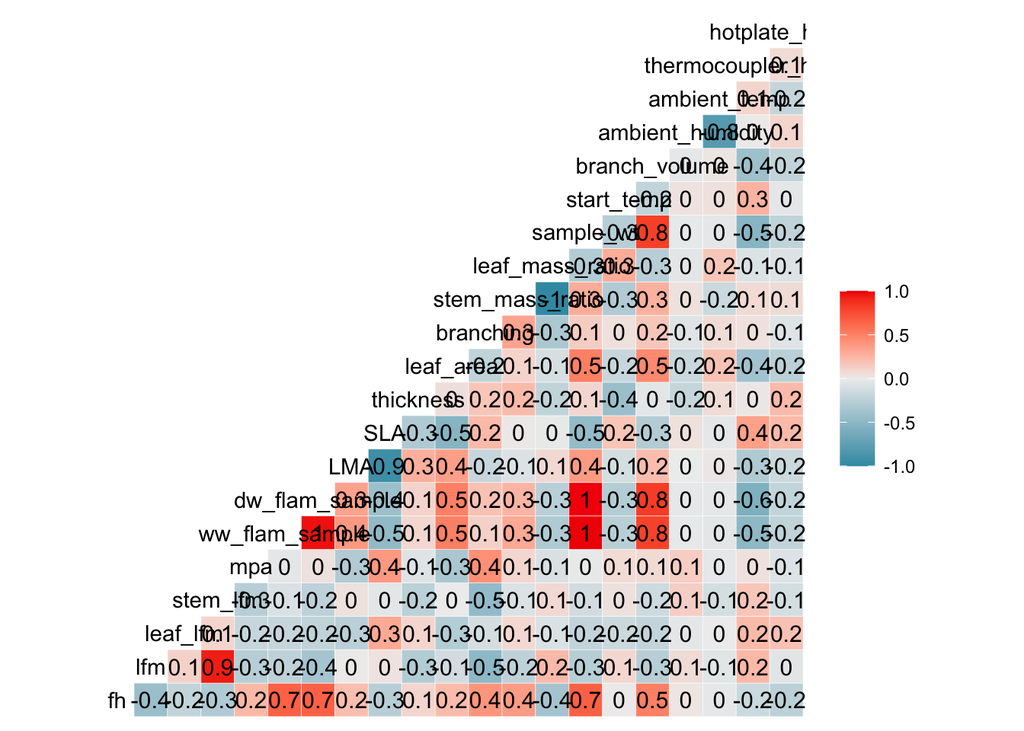

```r
flamm.df <- flamm.df %>%
  drop_na(fh) # dropping any NA's for flame height

flamm.df %>%
  select(fh, species, lfm, leaf_lfm, stem_lfm, mpa, ww_flam_sample, dw_flam_sample, LMA, SLA, thickness, leaf_area, branching, stem_mass_ratio, leaf_mass_ratio, sample_wt, start_temp, branch_volume, ambient_humidity, ambient_temp, thermocoupler_height, hotplate_height) %>%
  ggcorr(label = T)
```

From the above correlation matrix, there are some initial ‘problem areas’: - Sample weight and dw_flam_sample and ww_flam_sample: makes sense since sample weight was used in the calculation of these variables - Branch volume and sample weight, dw_flam_sample, ww_flam_sample: all describe bulkiness, size of sample in some way - LMA and SLA: duh - Leaf mass ratio and stem mass ratio: also, duh - Stem LFM and LFM - Leaf area and dw_flam_sample and ww_flam_sample: more of a surprising one to me, but makes sense conceptually

So, we will eliminate some variables from contention right away: - SLA: we can use LMA - Stem mass ratio: we can use leaf mass ratio - Stem LFM and leaf LFM: unless we notice something in the EDA that suggests otherwise, I think using total LFM makes sense - Leaf area: because leaf area is included in some fashion in the calculation of LMA and due to it’s oddly strong correlation to dw_flam_sample and ww_flam_sample which we’re interested in keeping in the models, it makes sense to remove

We can also eliminate ambient temp and humidity since they show absolutely no correlation with flame height (and very little correlation with most variables)

Just for fun, here’s an updated correlation matrix with those variables removed

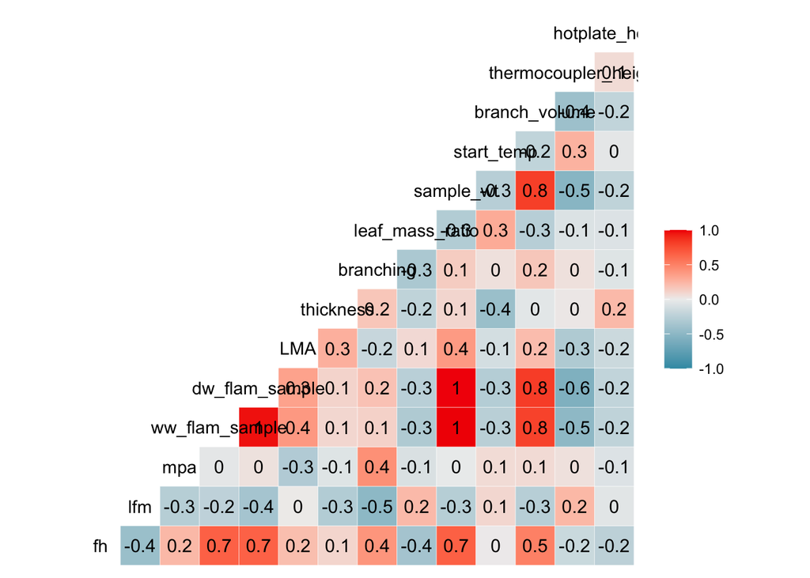

```r
flamm.df %>%
  filter(start_temp > 0) %>%  # to get rid of -inf values (when datalogger was off)
  select(fh, species, lfm, mpa, ww_flam_sample, dw_flam_sample, LMA, thickness, branching, leaf_mass_ratio, sample_wt, start_temp, branch_volume, thermocoupler_height, hotplate_height) %>%
  ggcorr(label = T)
```

Currently, there would be 14 predictors and covariates in the model structure which is far too many for an example. I’m going to cut out thickness, start_temp, thermocoupler_height and hotplate_height due to their limited correlations with flame height (note: i could’ve also removed mpa, but since the hydration question is something we’re generally more interested in, it made sense to keep it in there for now). 10 predictors and covariates is a lot, but it is certainly more managable than 14.

We need to do some basic data wrangling before we do anything with lmer

```r
# First, fixing 'plant' variable as described in blurb on data structure
flamm.df <- flamm.df %>%
  unite('plant_id', c(species, plant), sep = '_', remove = F)

# Now scaling all variables
scaled.flamm.df <- flamm.df %>%
  mutate(fh = scale(fh), lfm = scale(lfm), mpa = scale(mpa), ww_flam_sample = scale(ww_flam_sample), dw_flam_sample = scale(dw_flam_sample), LMA = scale(LMA), branching = scale(branching), leaf_mass_ratio = scale(leaf_mass_ratio), sample_wt = scale(sample_wt), branch_volume = scale(branch_volume))
```

Now, checking VIF scores of ‘full model’

```r
# Linear mixed effects model structure w/ lmer()
fh_full <- lmer(fh ~ species + lfm + mpa + ww_flam_sample + dw_flam_sample + LMA + branching + leaf_mass_ratio + sample_wt + branch_volume + (1|plant_id), data = scaled.flamm.df)
```

```
## fixed-effect model matrix is rank deficient so dropping 1 column / coefficient
```

```r
# Testing multicollinearity w/ performance package
multicollinearity(fh_full) # Ignore the low, moderate, high categories and focus on VIF scores
```

```
## # Check for Multicollinearity
##
## Low Correlation
##
##            Term    VIF       VIF 95% CI Increased SE Tolerance Tolerance 95% CI
##       branching   1.56     [1.34, 1.91]         1.25      0.64     [0.52, 0.75]
##             lfm   5.69     [4.51, 7.26]         2.38      0.18     [0.14, 0.22]
##         species 309.11 [238.29, 401.05]        17.58  3.24e-03     [0.00, 0.00]
##  ww_flam_sample  47.31 [ 36.58,  61.28]         6.88      0.02     [0.02, 0.03]
##  dw_flam_sample  57.01 [ 44.06,  73.87]         7.55      0.02     [0.01, 0.02]
##
## Moderate Correlation
##
##  Term  VIF   VIF 95% CI Increased SE Tolerance Tolerance 95% CI
##   LMA 4.00 [3.21, 5.06]         2.00      0.25     [0.20, 0.31]
##
## High Correlation
##
##             Term  VIF   VIF 95% CI Increased SE Tolerance Tolerance 95% CI
##              mpa 1.45 [1.26, 1.78]         1.21      0.69     [0.56, 0.79]
##  leaf_mass_ratio 2.85 [2.33, 3.58]         1.69      0.35     [0.28, 0.43]
##    branch_volume 3.04 [2.48, 3.82]         1.74      0.33     [0.26, 0.40]
```

LFM, ww_flam_sample, dw_flam_sample, and species all have VIF > 5. We may not need to remove all of them, but we will need to remove at least some of them. Although we’re interested in dw_flam_sample and ww_flam_sample, we learned from above correlation matrices that they are strongly correlated with sample_wt. Let’s remove them for now and we can try some models with them in the future to see if they improve the AIC score. Initially, I’m not totally sure why species has such an inflated VIF, so let’s take a look at the distribution of the other continuous variables as grouped by species to get a better sense of why this could be.

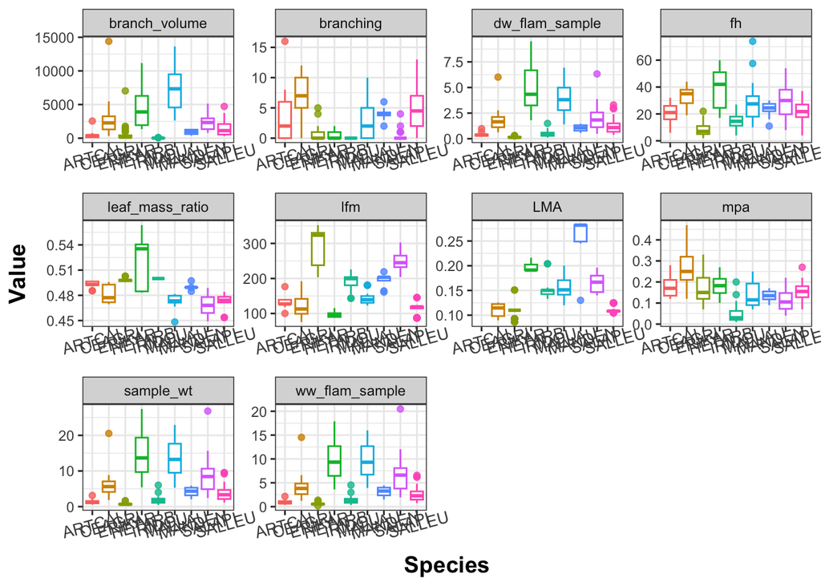

```r
flamm.df %>%
  select(fh, species, lfm, mpa, ww_flam_sample, dw_flam_sample, LMA, branching, leaf_mass_ratio, sample_wt, branch_volume) %>%
  pivot_longer(cols = !c(species), names_to = 'variable', values_to = 'value') %>%
  ggplot(aes(x = species, y = value, color = species)) +
    geom_boxplot(alpha = 0.8) +
    facet_wrap(~variable, scales = 'free') +
    labs(x = 'Species', y = 'Value') +
    theme_bw() +
    theme(legend.position = 'none',
          axis.title = element_text(face = 'bold', size = 14),
          axis.text.x = element_text(angle = 15, size = 10))
```

Trying out some model structures to try to eliminate multicollinearity while keeping species in the model

```r
fh_m1 <- lmer(fh ~ species + lfm + mpa + LMA + branching + sample_wt + branch_volume + (1|plant_id), data = scaled.flamm.df) # removed dw, ww, leaf mass ratio and kept in LMA
multicollinearity(fh_m1) # species and lfm still VIF > 5
```

```
## # Check for Multicollinearity
##
## Low Correlation
##
##           Term   VIF     VIF 95% CI Increased SE Tolerance Tolerance 95% CI
##      branching  1.49   [1.28, 1.83]         1.22      0.67     [0.55, 0.78]
##      sample_wt  3.50   [2.82, 4.43]         1.87      0.29     [0.23, 0.35]
##  branch_volume  2.82   [2.30, 3.55]         1.68      0.35     [0.28, 0.43]
##            lfm  5.41   [4.29, 6.92]         2.33      0.18     [0.14, 0.23]
##        species 60.75 [46.79, 78.96]         7.79      0.02     [0.01, 0.02]
##
## Moderate Correlation
##
##  Term  VIF   VIF 95% CI Increased SE Tolerance Tolerance 95% CI
##   LMA 3.96 [3.17, 5.02]         1.99      0.25     [0.20, 0.32]
##
## High Correlation
##
##  Term  VIF   VIF 95% CI Increased SE Tolerance Tolerance 95% CI
##   mpa 1.42 [1.24, 1.75]         1.19      0.70     [0.57, 0.81]
```

```r
fh_m2 <- lmer(fh ~ species + lfm + mpa + branching + sample_wt + branch_volume + (1|plant_id), data = scaled.flamm.df) # removed dw, ww, leaf mass ratio and LMA
multicollinearity(fh_m2) # species and lfm still VIF > 5
```

```
## # Check for Multicollinearity
##
## Low Correlation
##
##           Term   VIF     VIF 95% CI Increased SE Tolerance Tolerance 95% CI
##      sample_wt  3.69   [2.99, 4.65]         1.92      0.27     [0.22, 0.33]
##  branch_volume  2.96   [2.42, 3.71]         1.72      0.34     [0.27, 0.41]
##            lfm  5.47   [4.36, 6.94]         2.34      0.18     [0.14, 0.23]
##        species 21.47 [16.73, 27.62]         4.63      0.05     [0.04, 0.06]
##
## Moderate Correlation
##
##       Term  VIF   VIF 95% CI Increased SE Tolerance Tolerance 95% CI
##  branching 1.44 [1.26, 1.77]         1.20      0.69     [0.57, 0.80]
##
## High Correlation
##
##  Term  VIF   VIF 95% CI Increased SE Tolerance Tolerance 95% CI
##   mpa 1.44 [1.25, 1.76]         1.20      0.70     [0.57, 0.80]
```

```r
fh_m3 <- lmer(fh ~ species + mpa + branching + sample_wt + branch_volume + (1|plant_id), data = scaled.flamm.df) # removed dw, ww, leaf mass ratio, LMA, and lfm
multicollinearity(fh_m3) # no multicollinearity (removing lfm seemed to do the trick)
```

```
## # Check for Multicollinearity
##
## Low Correlation
##
##           Term  VIF   VIF 95% CI Increased SE Tolerance Tolerance 95% CI
##        species 4.71 [3.77, 5.97]         2.17      0.21     [0.17, 0.27]
##            mpa 1.44 [1.25, 1.76]         1.20      0.69     [0.57, 0.80]
##      branching 1.44 [1.26, 1.77]         1.20      0.69     [0.57, 0.80]
##      sample_wt 3.71 [2.99, 4.68]         1.93      0.27     [0.21, 0.33]
##  branch_volume 2.99 [2.44, 3.74]         1.73      0.33     [0.27, 0.41]
```

```r
fh_m4 <- lmer(fh ~ species + mpa + LMA + branching + sample_wt + branch_volume + (1|plant_id), data = scaled.flamm.df) # removed dw, ww, leaf mass ratio, and lfm
multicollinearity(fh_m4) # adding back in LMA made species VIF higher
```

```
## # Check for Multicollinearity
##
## Low Correlation
##
##           Term   VIF     VIF 95% CI Increased SE Tolerance Tolerance 95% CI
##            LMA  3.96   [3.17, 5.04]         1.99      0.25     [0.20, 0.32]
##      branching  1.49   [1.29, 1.84]         1.22      0.67     [0.54, 0.78]
##      sample_wt  3.51   [2.83, 4.46]         1.87      0.28     [0.22, 0.35]
##  branch_volume  2.85   [2.32, 3.59]         1.69      0.35     [0.28, 0.43]
##        species 13.68 [10.62, 17.70]         3.70      0.07     [0.06, 0.09]
##
## High Correlation
##
##  Term  VIF   VIF 95% CI Increased SE Tolerance Tolerance 95% CI
##   mpa 1.43 [1.24, 1.76]         1.19      0.70     [0.57, 0.81]
```

```r
fh_m5 <- lmer(fh ~ species + mpa + leaf_mass_ratio + branching + sample_wt + branch_volume + (1|plant_id), data = scaled.flamm.df) # removed dw, ww, LMA, and lfm
multicollinearity(fh_m5) # adding back in leaf mass ratio had less of an effect than adding LMA, but still made species VIF higher
```

```
## # Check for Multicollinearity
##
## Low Correlation
##
##             Term   VIF    VIF 95% CI Increased SE Tolerance Tolerance 95% CI
##  leaf_mass_ratio  2.66  [2.19, 3.32]         1.63      0.38     [0.30, 0.46]
##        branching  1.46  [1.27, 1.78]         1.21      0.69     [0.56, 0.79]
##        sample_wt  3.77  [3.05, 4.76]         1.94      0.26     [0.21, 0.33]
##    branch_volume  3.02  [2.47, 3.78]         1.74      0.33     [0.26, 0.41]
##          species 12.02 [9.43, 15.42]         3.47      0.08     [0.06, 0.11]
##
## High Correlation
##
##  Term  VIF   VIF 95% CI Increased SE Tolerance Tolerance 95% CI
##   mpa 1.46 [1.27, 1.79]         1.21      0.68     [0.56, 0.79]
```

```r
fh_m6 <- lmer(fh ~ species + mpa + branching + branch_volume + (1|plant_id), data = scaled.flamm.df) # removed dw, ww, leaf mass ratio, LMA, sample weight and lfm
multicollinearity(fh_m6) # no multicollinearity; sample weight may have been tied to species
```

```
## # Check for Multicollinearity
##
## Low Correlation
##
##           Term  VIF   VIF 95% CI Increased SE Tolerance Tolerance 95% CI
##        species 2.80 [2.29, 3.50]         1.67      0.36     [0.29, 0.44]
##            mpa 1.37 [1.20, 1.68]         1.17      0.73     [0.60, 0.83]
##      branching 1.32 [1.16, 1.62]         1.15      0.76     [0.62, 0.86]
##  branch_volume 1.78 [1.51, 2.19]         1.33      0.56     [0.46, 0.66]
```

```r
# Trying to re-add other variables to see how it affects species VIF
fh_m7 <- lmer(fh ~ species + mpa + LMA + branching + branch_volume + (1|plant_id), data = scaled.flamm.df) # removed dw, ww, leaf mass ratio, sample weight and lfm
multicollinearity(fh_m7) # species VIF > 5
```

```
## # Check for Multicollinearity
##
## Low Correlation
##
##           Term  VIF    VIF 95% CI Increased SE Tolerance Tolerance 95% CI
##            LMA 3.88  [3.11, 4.94]         1.97      0.26     [0.20, 0.32]
##      branching 1.34  [1.18, 1.66]         1.16      0.74     [0.60, 0.85]
##  branch_volume 1.71  [1.45, 2.12]         1.31      0.58     [0.47, 0.69]
##        species 9.11 [7.11, 11.77]         3.02      0.11     [0.08, 0.14]
##
## Moderate Correlation
##
##  Term  VIF   VIF 95% CI Increased SE Tolerance Tolerance 95% CI
##   mpa 1.35 [1.18, 1.67]         1.16      0.74     [0.60, 0.85]
```

```r
fh_m8 <- lmer(fh ~ species + mpa + leaf_mass_ratio + branching + branch_volume + (1|plant_id), data = scaled.flamm.df) # removed dw, ww, LMA, sample weight and lfm
multicollinearity(fh_m8) # species VIF > 5
```

```
## # Check for Multicollinearity
##
## Low Correlation
##
##             Term  VIF   VIF 95% CI Increased SE Tolerance Tolerance 95% CI
##  leaf_mass_ratio 2.60 [2.14, 3.25]         1.61      0.38     [0.31, 0.47]
##        branching 1.34 [1.18, 1.65]         1.16      0.74     [0.61, 0.85]
##    branch_volume 1.81 [1.53, 2.23]         1.34      0.55     [0.45, 0.65]
##          species 7.18 [5.68, 9.17]         2.68      0.14     [0.11, 0.18]
##
## Moderate Correlation
##
##  Term  VIF   VIF 95% CI Increased SE Tolerance Tolerance 95% CI
##   mpa 1.40 [1.22, 1.71]         1.18      0.71     [0.58, 0.82]
```

```r
fh_m9 <- lmer(fh ~ species + mpa + lfm + leaf_mass_ratio + branching + branch_volume + (1|plant_id), data = scaled.flamm.df) # removed dw, ww, LMA, and sample weight
multicollinearity(fh_m9) # species and lfm both VIF > 5
```

```
## # Check for Multicollinearity
##
## Low Correlation
##
##             Term   VIF     VIF 95% CI Increased SE Tolerance Tolerance 95% CI
##  leaf_mass_ratio  2.60   [2.14, 3.24]         1.61      0.38     [0.31, 0.47]
##    branch_volume  1.80   [1.53, 2.21]         1.34      0.56     [0.45, 0.66]
##              lfm  5.46   [4.35, 6.94]         2.34      0.18     [0.14, 0.23]
##          species 33.31 [25.90, 42.93]         5.77      0.03     [0.02, 0.04]
##
## Moderate Correlation
##
##       Term  VIF   VIF 95% CI Increased SE Tolerance Tolerance 95% CI
##  branching 1.34 [1.18, 1.65]         1.16      0.74     [0.61, 0.84]
##
## High Correlation
##
##  Term  VIF   VIF 95% CI Increased SE Tolerance Tolerance 95% CI
##   mpa 1.39 [1.22, 1.71]         1.18      0.72     [0.59, 0.82]
```

```r
fh_m10 <- lmer(fh ~ species + mpa + dw_flam_sample + leaf_mass_ratio + branching + branch_volume + (1|plant_id), data = scaled.flamm.df) # removed ww, LMA, sample weight and lfm
multicollinearity(fh_m10) # Species VIF > 5
```

```
## # Check for Multicollinearity
##
## Low Correlation
##
##             Term   VIF    VIF 95% CI Increased SE Tolerance Tolerance 95% CI
##   dw_flam_sample  4.21  [3.39, 5.32]         2.05      0.24     [0.19, 0.30]
##  leaf_mass_ratio  2.69  [2.21, 3.35]         1.64      0.37     [0.30, 0.45]
##        branching  1.47  [1.28, 1.80]         1.21      0.68     [0.56, 0.78]
##    branch_volume  3.13  [2.55, 3.92]         1.77      0.32     [0.26, 0.39]
##          species 12.68 [9.93, 16.26]         3.56      0.08     [0.06, 0.10]
##
## High Correlation
##
##  Term  VIF   VIF 95% CI Increased SE Tolerance Tolerance 95% CI
##   mpa 1.44 [1.26, 1.77]         1.20      0.69     [0.57, 0.80]
```

```r
fh_m11 <- lmer(fh ~ species + mpa + ww_flam_sample + leaf_mass_ratio + branching + branch_volume + (1|plant_id), data = scaled.flamm.df) # removed dw, LMA, sample weight and lfm
multicollinearity(fh_m11) # Species VIF > 5
```

```
## # Check for Multicollinearity
##
## Low Correlation
##
##             Term   VIF    VIF 95% CI Increased SE Tolerance Tolerance 95% CI
##   ww_flam_sample  3.59  [2.91, 4.52]         1.89      0.28     [0.22, 0.34]
##  leaf_mass_ratio  2.65  [2.18, 3.31]         1.63      0.38     [0.30, 0.46]
##        branching  1.45  [1.26, 1.77]         1.20      0.69     [0.56, 0.79]
##    branch_volume  2.95  [2.41, 3.69]         1.72      0.34     [0.27, 0.41]
##          species 11.90 [9.33, 15.25]         3.45      0.08     [0.07, 0.11]
##
## High Correlation
##
##  Term  VIF   VIF 95% CI Increased SE Tolerance Tolerance 95% CI
##   mpa 1.47 [1.28, 1.80]         1.21      0.68     [0.56, 0.78]
```

Okay, it seems like if we keep species in, we’ll have to make some significant sacrifices elsewhere in the model to avoid breaking multicollinearity assumptions. Let’s try some model structures w/ removing species:

```r
fh_m12 <- lmer(fh ~ lfm + mpa + ww_flam_sample + dw_flam_sample + LMA + branching + leaf_mass_ratio + sample_wt + branch_volume + (1|plant_id), data = scaled.flamm.df)
```

```
## fixed-effect model matrix is rank deficient so dropping 1 column / coefficient
```

```r
multicollinearity(fh_m12) # ww and dw are collinear
```

```
## # Check for Multicollinearity
##
## Low Correlation
##
##             Term   VIF     VIF 95% CI Increased SE Tolerance Tolerance 95% CI
##              lfm  1.63   [1.38, 2.02]         1.27      0.62     [0.50, 0.72]
##              mpa  1.11   [1.02, 1.50]         1.05      0.90     [0.67, 0.98]
##  leaf_mass_ratio  1.26   [1.12, 1.57]         1.12      0.80     [0.64, 0.90]
##    branch_volume  2.44   [2.00, 3.08]         1.56      0.41     [0.32, 0.50]
##   ww_flam_sample 24.99 [19.18, 32.66]         5.00      0.04     [0.03, 0.05]
##   dw_flam_sample 28.23 [21.64, 36.90]         5.31      0.04     [0.03, 0.05]
##
## High Correlation
##
##       Term  VIF   VIF 95% CI Increased SE Tolerance Tolerance 95% CI
##        LMA 1.24 [1.10, 1.55]         1.11      0.81     [0.64, 0.91]
##  branching 1.24 [1.11, 1.56]         1.11      0.80     [0.64, 0.90]
```

```r
fh_m13 <- lmer(fh ~ lfm + mpa + LMA + branching + leaf_mass_ratio + sample_wt + branch_volume + (1|plant_id), data = scaled.flamm.df) # no ww or dw
multicollinearity(fh_m13) # no multicollinearity
```

```
## # Check for Multicollinearity
##
## Low Correlation
##
##             Term  VIF   VIF 95% CI Increased SE Tolerance Tolerance 95% CI
##              lfm 1.18 [1.06, 1.51]         1.09      0.85     [0.66, 0.94]
##              mpa 1.10 [1.02, 1.51]         1.05      0.91     [0.66, 0.98]
##              LMA 1.24 [1.10, 1.55]         1.11      0.81     [0.64, 0.91]
##        branching 1.23 [1.10, 1.55]         1.11      0.81     [0.65, 0.91]
##  leaf_mass_ratio 1.08 [1.01, 1.61]         1.04      0.93     [0.62, 0.99]
##        sample_wt 2.67 [2.17, 3.38]         1.63      0.37     [0.30, 0.46]
##    branch_volume 2.36 [1.94, 2.98]         1.54      0.42     [0.34, 0.52]
```

```r
fh_m14 <- lmer(fh ~ mpa + lfm  + dw_flam_sample + LMA + branching + leaf_mass_ratio + branch_volume + (1|plant_id), data = scaled.flamm.df) # no ww or sample wt
multicollinearity(fh_m14) # no multicollinearity
```

```
## # Check for Multicollinearity
##
## Low Correlation
##
##             Term  VIF   VIF 95% CI Increased SE Tolerance Tolerance 95% CI
##              mpa 1.09 [1.02, 1.54]         1.04      0.92     [0.65, 0.98]
##              lfm 1.23 [1.10, 1.55]         1.11      0.81     [0.65, 0.91]
##   dw_flam_sample 2.84 [2.30, 3.61]         1.69      0.35     [0.28, 0.43]
##              LMA 1.22 [1.09, 1.54]         1.10      0.82     [0.65, 0.92]
##        branching 1.23 [1.10, 1.55]         1.11      0.81     [0.65, 0.91]
##  leaf_mass_ratio 1.07 [1.01, 1.69]         1.03      0.94     [0.59, 0.99]
##    branch_volume 2.41 [1.97, 3.04]         1.55      0.42     [0.33, 0.51]
```

```r
fh_m15 <- lmer(fh ~ mpa + lfm  + ww_flam_sample + LMA + branching + leaf_mass_ratio + branch_volume + (1|plant_id), data = scaled.flamm.df) # no ww or sample wt
multicollinearity(fh_m15) # no multicollinearity
```

```
## # Check for Multicollinearity
##
## Low Correlation
##
##             Term  VIF   VIF 95% CI Increased SE Tolerance Tolerance 95% CI
##              mpa 1.10 [1.02, 1.51]         1.05      0.91     [0.66, 0.98]
##              lfm 1.17 [1.06, 1.50]         1.08      0.85     [0.67, 0.95]
##   ww_flam_sample 2.56 [2.09, 3.24]         1.60      0.39     [0.31, 0.48]
##              LMA 1.24 [1.10, 1.55]         1.11      0.81     [0.64, 0.91]
##        branching 1.23 [1.10, 1.55]         1.11      0.81     [0.65, 0.91]
##  leaf_mass_ratio 1.08 [1.01, 1.56]         1.04      0.92     [0.64, 0.99]
##    branch_volume 2.30 [1.89, 2.90]         1.52      0.43     [0.35, 0.53]
```

```r
fh_m16 <- lmer(fh ~ mpa + dw_flam_sample + ww_flam_sample + LMA + branching + leaf_mass_ratio + branch_volume + (1|plant_id), data = scaled.flamm.df)
multicollinearity(fh_m16) # ww and dw are collinear
```

```
## # Check for Multicollinearity
##
## Low Correlation
##
##             Term   VIF     VIF 95% CI Increased SE Tolerance Tolerance 95% CI
##              mpa  1.10   [1.02, 1.51]         1.05      0.91     [0.66, 0.98]
##  leaf_mass_ratio  1.21   [1.09, 1.53]         1.10      0.82     [0.65, 0.92]
##    branch_volume  2.42   [1.99, 3.06]         1.56      0.41     [0.33, 0.50]
##   dw_flam_sample 20.35 [15.62, 26.61]         4.51      0.05     [0.04, 0.06]
##   ww_flam_sample 19.13 [14.69, 25.01]         4.37      0.05     [0.04, 0.07]
##
## High Correlation
##
##       Term  VIF   VIF 95% CI Increased SE Tolerance Tolerance 95% CI
##        LMA 1.23 [1.10, 1.55]         1.11      0.81     [0.65, 0.91]
##  branching 1.22 [1.09, 1.54]         1.11      0.82     [0.65, 0.92]
```

Without species in the model, we can do a lot more w/ the model structure. Multicollinearity becomes an issue with LFM, DW, WW, and sample weight. DW or WW and LFM can be in the same model (see fh_m14 and fh_m15), but DW, WW, and sample_wt all need to be considered in separate models. Now we have a decent understanding of which variables could be included in the more in-depth model selection

## Interaction Check

Although I don’t plan on including interaction terms in the AIC-based selection (below) for this example, as it would make the selection even more complicated than it already is, it is worth checking to see whether there is evidence that there should/could be interaction terms included in the fixed and/or random effects. I am also using this chunk as a trial of interaction.plot()

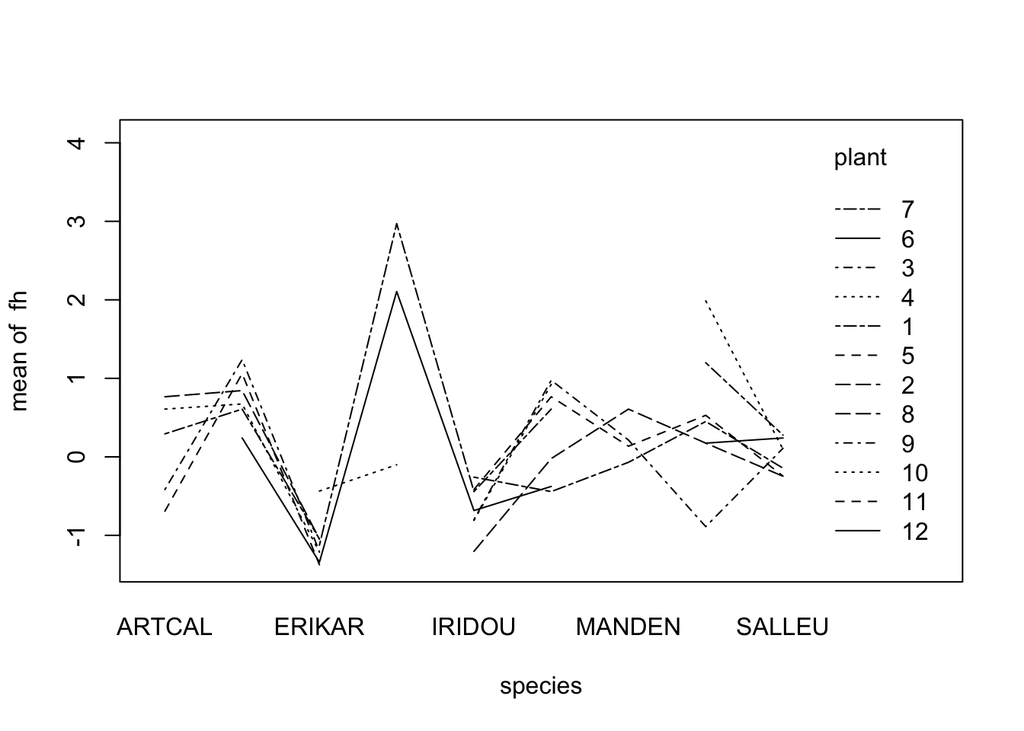

```r
with(scaled.flamm.df, {
  interaction.plot(species, plant, fh)
  interaction.plot(species, plant, fh)})
```

## AIC-Based Selection

We have been focused on using AIC to select the ‘best’ models in the mixed effects model selection. Below, I tried all of the permutations w/o interactions to see which predictor variables are selected in the top models. Interaction terms with species may be important in the final model selection, but to make things a bit simpler for this example, I decided against using any.

Also, note that I started over at fh_m1 below (throwing coding best practices out the window), but that the below models in no way relate to the multicollinearity check above

Starting w/ models with species in, we have mpa, leaf_mass_ratio, branching and branch_volume in the model without multicollinearity with the most variables. Assuming we want to keep species in the model, there are 4 variables that could be arranged in 15 different ways. I also tried some models with just species and a single other variable (e.g., LMA, lfm, dw) to see if that’d work

```r
fh_m1 <- lmer(fh ~ species + mpa + leaf_mass_ratio + branching + branch_volume + (1|plant_id), data = scaled.flamm.df, REML = F)
multicollinearity(fh_m1) # VIF > 5 for species (note, changed REML = T to double-check and it was still VIF > 5)

fh_m2 <- lmer(fh ~ species + mpa + branching + branch_volume + (1|plant_id), data = scaled.flamm.df, REML = F)
multicollinearity(fh_m2)

fh_m3 <- lmer(fh ~ species + mpa + branch_volume + (1|plant_id), data = scaled.flamm.df, REML = F)
multicollinearity(fh_m3)

fh_m4 <- lmer(fh ~ species + mpa + branching + (1|plant_id), data = scaled.flamm.df, REML = F)
multicollinearity(fh_m4)

fh_m5 <- lmer(fh ~ species + branching + branch_volume + (1|plant_id), data = scaled.flamm.df, REML = F)
multicollinearity(fh_m5)

fh_m6 <- lmer(fh ~ species + mpa + (1|plant_id), data = scaled.flamm.df, REML = F)
multicollinearity(fh_m6)

fh_m7 <- lmer(fh ~ species + branch_volume + (1|plant_id), data = scaled.flamm.df, REML = F)
multicollinearity(fh_m7)

fh_m8 <- lmer(fh ~ species + branching + (1|plant_id), data = scaled.flamm.df, REML = F)
multicollinearity(fh_m8)

fh_m9 <- lmer(fh ~ species + leaf_mass_ratio + (1|plant_id), data = scaled.flamm.df, REML = F)
multicollinearity(fh_m9)

fh_m10 <- lmer(fh ~ species + mpa + leaf_mass_ratio + branch_volume + (1|plant_id), data = scaled.flamm.df, REML = F)
multicollinearity(fh_m10)

fh_m11 <- lmer(fh ~ species + mpa + leaf_mass_ratio + branching + (1|plant_id), data = scaled.flamm.df, REML = F)
multicollinearity(fh_m11)

fh_m12 <- lmer(fh ~ species + leaf_mass_ratio + branching + branch_volume + (1|plant_id), data = scaled.flamm.df, REML = T)
multicollinearity(fh_m12) # VIF > 5 for species (note, changed REML = T to double-check and it was still VIF > 5)

fh_m13 <- lmer(fh ~ species + mpa + leaf_mass_ratio + (1|plant_id), data = scaled.flamm.df, REML = F)
multicollinearity(fh_m13)

fh_m14 <- lmer(fh ~ species + leaf_mass_ratio + branch_volume + (1|plant_id), data = scaled.flamm.df, REML = F)
multicollinearity(fh_m14)

fh_m15 <- lmer(fh ~ species + leaf_mass_ratio + branching + (1|plant_id), data = scaled.flamm.df, REML = F)
multicollinearity(fh_m15)

fh_m16 <- lmer(fh ~ species + lfm + (1|plant_id), data = scaled.flamm.df, REML = F)
multicollinearity(fh_m16) # breaks multicollinearity assumption

fh_m17 <- lmer(fh ~ species + LMA + (1|plant_id), data = scaled.flamm.df, REML = F)
multicollinearity(fh_m17)

fh_m18 <- lmer(fh ~ species + dw_flam_sample + (1|plant_id), data = scaled.flamm.df, REML = F)
multicollinearity(fh_m18)

fh_m19 <- lmer(fh ~ species + ww_flam_sample + (1|plant_id), data = scaled.flamm.df, REML = F)
multicollinearity(fh_m19)

fh_m20 <- lmer(fh ~ species + sample_wt + (1|plant_id), data = scaled.flamm.df, REML = F)
multicollinearity(fh_m20)
```

```r
tab_model(fh_m2, fh_m3, fh_m4, fh_m5, fh_m6, fh_m7, fh_m8, fh_m9, fh_m10,
          fh_m11, fh_m13, fh_m14, fh_m15, fh_m17, fh_m18, fh_m19, fh_m20,
          show.reflvl = TRUE,
          digits = 3,
          show.aic = TRUE,
          show.ci = FALSE,
          show.icc = FALSE,
          string.pred = "Coeffcient",
         title = "MEM Selection: Flame Height, Species in Models",
  string.p = "P-Value",
  p.style = "stars")
```

MEM Selection: Flame Height, Species in Models

fh

fh

fh

fh

fh

fh

fh

fh

fh

fh

fh

fh

fh

fh

fh

fh

fh

Coeffcient

Estimates

Estimates

Estimates

Estimates

Estimates

Estimates

Estimates

Estimates

Estimates

Estimates

Estimates

Estimates

Estimates

Estimates

Estimates

Estimates

Estimates

(Intercept)

-0.060

0.070

-0.193

-0.048

-0.085

0.085

-0.180

0.047

0.178

-0.087

0.033

0.193

-0.074

0.829 **

0.255

0.288

0.282

branch_volume

0.228 **

0.299 ***

0.223 **

0.293 ***

0.294 ***

0.290 ***

branching

0.259 ***

0.302 ***

0.262 ***

0.304 ***

0.289 ***

0.290 ***

dw_flam_sample

0.534 ***

leaf_mass_ratio

-0.305 **

-0.280 **

-0.247 *

-0.298 **

-0.288 **

-0.253 *

LMA

0.058

mpa

0.086

0.099

0.074

0.083

0.082

0.061

0.065

sample_wt

0.542 ***

ARTCAL

*Reference*

*Reference*

*Reference*

*Reference*

*Reference*

*Reference*

*Reference*

*Reference*

*Reference*

*Reference*

*Reference*

*Reference*

*Reference*

*Reference*

*Reference*

*Reference*

*Reference*

CEAGRI

0.371

0.532

0.501

0.482

0.753 *

0.661 *

0.595

0.670 *

0.383

0.374

0.592

0.485

0.447

0.461

0.483

0.472

ERIKAR

-0.715 *

-0.959 **

-0.677 *

-0.714 *

-0.961 **

-0.961 **

-0.676 *

-0.841 **

-0.847 **

-0.594

-0.842 **

-0.846 **

-0.591

-1.822 ***

-0.854 **

-0.882 **

-0.873 **

HETARB

1.356 ***

0.981 *

1.780 ***

1.374 ***

1.475 ***

0.997 *

1.787 ***

1.963 ***

1.435 ***

2.154 ***

1.947 ***

1.463 ***

2.169 ***

0.501

-0.147

0.155

0.049

IRIDOU

-0.106

-0.376

-0.123

-0.224

-0.462

-0.514

-0.223

-0.415

-0.251

-0.031

-0.329

-0.362

-0.110

-1.500 ***

-0.573

-0.605 *

-0.595 *

MALLAU

0.349

0.079

0.968 **

0.333

0.866 *

0.059

0.943 **

0.458

-0.259

0.652

0.489

-0.286

0.623

-0.086

-0.395

-0.444

-0.443

MANDEN

0.299

0.257

0.327

0.265

0.280

0.218

0.298

0.210

0.215

0.286

0.237

0.181

0.261

-0.787

0.091

0.013

0.034

SALAPI

0.934 **

0.622

1.133 ***

0.884 **

0.820 *

0.561

1.086 **

0.349

0.231

0.774 *

0.401

0.168

0.726 *

-0.171

0.214

-0.100

-0.015

SALLEU

-0.024

-0.002

0.047

-0.049

0.101

-0.030

0.024

-0.277

-0.329

-0.244

-0.250

-0.362

-0.271

-0.784 *

-0.199

-0.157

-0.172

ww_flam_sample

0.543 ***

Random Effects

σ<sup>2</sup>

0.25

0.28

0.26

0.26

0.30

0.29

0.26

0.30

0.28

0.26

0.30

0.29

0.26

0.29

0.26

0.25

0.25

τ<sub>00</sub>

0.22 <sub>plant_id</sub>

0.23 <sub>plant_id</sub>

0.27 <sub>plant_id</sub>

0.22 <sub>plant_id</sub>

0.28 <sub>plant_id</sub>

0.23 <sub>plant_id</sub>

0.27 <sub>plant_id</sub>

0.22 <sub>plant_id</sub>

0.19 <sub>plant_id</sub>

0.24 <sub>plant_id</sub>

0.23 <sub>plant_id</sub>

0.18 <sub>plant_id</sub>

0.23 <sub>plant_id</sub>

0.31 <sub>plant_id</sub>

0.17 <sub>plant_id</sub>

0.17 <sub>plant_id</sub>

0.17 <sub>plant_id</sub>

N

66 <sub>plant_id</sub>

66 <sub>plant_id</sub>

66 <sub>plant_id</sub>

66 <sub>plant_id</sub>

66 <sub>plant_id</sub>

66 <sub>plant_id</sub>

66 <sub>plant_id</sub>

66 <sub>plant_id</sub>

66 <sub>plant_id</sub>

66 <sub>plant_id</sub>

66 <sub>plant_id</sub>

66 <sub>plant_id</sub>

66 <sub>plant_id</sub>

59 <sub>plant_id</sub>

66 <sub>plant_id</sub>

66 <sub>plant_id</sub>

66 <sub>plant_id</sub>

Observations

196

196

196

196

196

196

196

196

196

196

196

196

196

183

196

196

196

Marginal R<sup>2</sup> / Conditional R<sup>2</sup>

0.555 / 0.762

0.525 / 0.738

0.525 / 0.770

0.553 / 0.758

0.482 / 0.732

0.522 / 0.734

0.524 / 0.766

0.514 / 0.719

0.554 / 0.730

0.549 / 0.766

0.514 / 0.723

0.553 / 0.727

0.549 / 0.763

0.488 / 0.750

0.587 / 0.755

0.595 / 0.757

0.594 / 0.756

AIC

414.233

425.391

417.328

410.337

434.924

421.841

413.073

428.862

423.928

417.421

433.329

419.876

412.831

405.019

395.143

392.227

392.613

- p<0.05 ** p<0.01 *** p<0.001

From the above model selection, dw_flam_sample, ww_flam_sample and sample weight emerged as key predictors when paired w/ species.

Before we delve into that a bit further (to see which other variables we could potentially pair with dw or ww in a model), let’s do a selection without species. For this selection, since we have 9 predictor variables (although some of them cannot be paired with each other (see multicollinearity notes on LFM, dw, ww, sample weight above)), we will have to approach it a different way, or else we’d have WAY too many possible permutations of predictors. In this model selection, the idea is to whittle down the ‘bad’ predictors so that we can get to a manageable level of predictors.

```r
fh_m21 <- lmer(fh ~ lfm + mpa + dw_flam_sample + LMA + branching + leaf_mass_ratio + branch_volume + (1|plant_id), data = scaled.flamm.df, REML = F)
multicollinearity(fh_m21)

fh_m22 <- lmer(fh ~ lfm + mpa + sample_wt + LMA + branching + leaf_mass_ratio + branch_volume + (1|plant_id), data = scaled.flamm.df, REML = F)
multicollinearity(fh_m22)

fh_m23 <- lmer(fh ~ lfm + mpa + LMA + branching + leaf_mass_ratio + branch_volume + (1|plant_id), data = scaled.flamm.df, REML = F)
multicollinearity(fh_m23)

# Removing LFM
fh_m24 <- lmer(fh ~ mpa + dw_flam_sample + LMA + branching + leaf_mass_ratio + branch_volume + (1|plant_id), data = scaled.flamm.df, REML = F)
multicollinearity(fh_m24)

fh_m25 <- lmer(fh ~ mpa + sample_wt + LMA + branching + leaf_mass_ratio + branch_volume + (1|plant_id), data = scaled.flamm.df, REML = F)
multicollinearity(fh_m25)

fh_m26 <- lmer(fh ~ mpa + LMA + branching + leaf_mass_ratio + branch_volume + (1|plant_id), data = scaled.flamm.df, REML = F)
multicollinearity(fh_m26)

# Removing MPa
fh_m27 <- lmer(fh ~ lfm + dw_flam_sample + LMA + branching + leaf_mass_ratio + branch_volume + (1|plant_id), data = scaled.flamm.df, REML = F)
multicollinearity(fh_m27)

fh_m28 <- lmer(fh ~ lfm + sample_wt + LMA + branching + leaf_mass_ratio + branch_volume + (1|plant_id), data = scaled.flamm.df, REML = F)
multicollinearity(fh_m28)

fh_m29 <- lmer(fh ~ lfm + LMA + branching + leaf_mass_ratio + branch_volume + (1|plant_id), data = scaled.flamm.df, REML = F)
multicollinearity(fh_m29)

# Removing LMA
fh_m30 <- lmer(fh ~ lfm + mpa + dw_flam_sample + branching + leaf_mass_ratio + branch_volume + (1|plant_id), data = scaled.flamm.df, REML = F)
multicollinearity(fh_m30)

fh_m31 <- lmer(fh ~ lfm + mpa + sample_wt + branching + leaf_mass_ratio + branch_volume + (1|plant_id), data = scaled.flamm.df, REML = F)
multicollinearity(fh_m31)

fh_m32 <- lmer(fh ~ lfm + mpa + branching + leaf_mass_ratio + branch_volume + (1|plant_id), data = scaled.flamm.df, REML = F)
multicollinearity(fh_m32)

# Removing branching
fh_m33 <- lmer(fh ~ lfm + mpa + dw_flam_sample + LMA + leaf_mass_ratio + branch_volume + (1|plant_id), data = scaled.flamm.df, REML = F)
multicollinearity(fh_m33)

fh_m34 <- lmer(fh ~ lfm + mpa + sample_wt + LMA + leaf_mass_ratio + branch_volume + (1|plant_id), data = scaled.flamm.df, REML = F)
multicollinearity(fh_m34)

fh_m35 <- lmer(fh ~ lfm + mpa + LMA + leaf_mass_ratio + branch_volume + (1|plant_id), data = scaled.flamm.df, REML = F)
multicollinearity(fh_m35)

# Removing leaf mass ratio
fh_m36 <- lmer(fh ~ lfm + mpa + dw_flam_sample + LMA + branching + branch_volume + (1|plant_id), data = scaled.flamm.df, REML = F)
multicollinearity(fh_m36)

fh_m37 <- lmer(fh ~ lfm + mpa + sample_wt + LMA + branching + branch_volume + (1|plant_id), data = scaled.flamm.df, REML = F)
multicollinearity(fh_m37)

fh_m38 <- lmer(fh ~ lfm + mpa + LMA + branching + branch_volume + (1|plant_id), data = scaled.flamm.df, REML = F)
multicollinearity(fh_m38)

# Removing volume
fh_m39 <- lmer(fh ~ lfm + mpa + dw_flam_sample + LMA + branching + leaf_mass_ratio + (1|plant_id), data = scaled.flamm.df, REML = F)
multicollinearity(fh_m39)

fh_m40 <- lmer(fh ~ lfm + mpa + sample_wt + LMA + branching + leaf_mass_ratio + (1|plant_id), data = scaled.flamm.df, REML = F)
multicollinearity(fh_m40)

fh_m41 <- lmer(fh ~ lfm + mpa + LMA + branching + leaf_mass_ratio + (1|plant_id), data = scaled.flamm.df, REML = F)
multicollinearity(fh_m41)
```

```r
tab_model(fh_m21, fh_m22, fh_m23, fh_m24, fh_m25, fh_m26, fh_m27, fh_m28, fh_m29, fh_m30,
          fh_m31, fh_m32, fh_m33, fh_m34, fh_m35, fh_m36, fh_m37, fh_m38, fh_m39, fh_m40,
          fh_m41,
          show.reflvl = TRUE,
          digits = 3,
          dv.labels = c(rep('full', 3), rep('no lfm', 3), rep('no mpa', 3), rep('no lma', 3),
                        rep('no branching', 3), rep('no leaf mass ratio', 3), rep('no volume', 3)),
          show.aic = TRUE,
          show.ci = FALSE,
          show.icc = FALSE,
          string.pred = "Coeffcient",
         title = "MEM Selection: Flame Height, No Species in Models",
  string.p = "P-Value",
  p.style = "stars")
```

MEM Selection: Flame Height, No Species in Models

full

full

full

no lfm

no lfm

no lfm

no mpa

no mpa

no mpa

no lma

no lma

no lma

no branching

no branching

no branching

no leaf mass ratio

no leaf mass ratio

no leaf mass ratio

no volume

no volume

no volume

Coeffcient

Estimates

Estimates

Estimates

Estimates

Estimates

Estimates

Estimates

Estimates

Estimates

Estimates

Estimates

Estimates

Estimates

Estimates

Estimates

Estimates

Estimates

Estimates

Estimates

Estimates

Estimates

(Intercept)

0.051

0.046

0.117

0.046

0.039

0.110

0.055

0.051

0.121

0.086

0.072

0.164

0.034

0.030

0.092

0.055

0.047

0.121

0.050

0.045

0.174

branch_volume

-0.091

-0.112

0.245 ***

-0.093

-0.103

0.265 ***

-0.090

-0.107

0.240 ***

-0.109

-0.131

0.288 ***

-0.088

-0.106

0.284 ***

-0.063

-0.101

0.258 ***

branching

0.134 *

0.137 *

0.190 **

0.142 *

0.157 **

0.215 ***

0.158 *

0.164 **

0.208 **

0.147 **

0.153 **

0.186 **

0.156 *

0.155 *

0.209 **

0.133 *

0.135 *

0.245 ***

dw_flam_sample

0.552 ***

0.569 ***

0.545 ***

0.600 ***

0.581 ***

0.541 ***

0.478 ***

leaf_mass_ratio

-0.187 **

-0.144 *

-0.177 *

-0.186 **

-0.141 *

-0.175 *

-0.186 **

-0.144 *

-0.178 *

-0.167 *

-0.123

-0.152

-0.210 **

-0.167 *

-0.210 *

-0.178 *

-0.139 *

-0.217 *

lfm

-0.069

-0.136

-0.208

-0.096

-0.164

-0.233 *

-0.067

-0.135

-0.207

-0.106

-0.179 *

-0.266 *

-0.068

-0.132

-0.206

-0.074

-0.129

-0.286 *

LMA

0.147

0.124

0.313 **

0.147

0.130

0.331 **

0.119

0.097

0.287 **

0.118

0.096

0.278 **

0.131

0.106

0.296 **

0.155

0.135

0.391 ***

mpa

0.144 *

0.155 *

0.130

0.150 *

0.167 **

0.145 *

0.115

0.129 *

0.084

0.168 **

0.181 **

0.162 *

0.144 *

0.154 *

0.130

0.144 *

0.153 *

0.118

sample_wt

0.590 ***

0.604 ***

0.576 ***

0.636 ***

0.613 ***

0.600 ***

0.500 ***

Random Effects

σ<sup>2</sup>

0.23

0.23

0.24

0.23

0.23

0.24

0.23

0.23

0.25

0.23

0.23

0.25

0.23

0.23

0.27

0.23

0.23

0.24

0.23

0.22

0.24

τ<sub>00</sub>

0.29 <sub>plant_id</sub>

0.25 <sub>plant_id</sub>

0.45 <sub>plant_id</sub>

0.29 <sub>plant_id</sub>

0.26 <sub>plant_id</sub>

0.48 <sub>plant_id</sub>

0.30 <sub>plant_id</sub>

0.27 <sub>plant_id</sub>

0.47 <sub>plant_id</sub>

0.27 <sub>plant_id</sub>

0.23 <sub>plant_id</sub>

0.48 <sub>plant_id</sub>

0.29 <sub>plant_id</sub>

0.25 <sub>plant_id</sub>

0.42 <sub>plant_id</sub>

0.34 <sub>plant_id</sub>

0.28 <sub>plant_id</sub>

0.50 <sub>plant_id</sub>

0.29 <sub>plant_id</sub>

0.26 <sub>plant_id</sub>

0.59 <sub>plant_id</sub>

N

59 <sub>plant_id</sub>

59 <sub>plant_id</sub>

59 <sub>plant_id</sub>

59 <sub>plant_id</sub>

59 <sub>plant_id</sub>

59 <sub>plant_id</sub>

59 <sub>plant_id</sub>

59 <sub>plant_id</sub>

59 <sub>plant_id</sub>

66 <sub>plant_id</sub>

66 <sub>plant_id</sub>

66 <sub>plant_id</sub>

59 <sub>plant_id</sub>

59 <sub>plant_id</sub>

59 <sub>plant_id</sub>

59 <sub>plant_id</sub>

59 <sub>plant_id</sub>

59 <sub>plant_id</sub>

59 <sub>plant_id</sub>

59 <sub>plant_id</sub>

59 <sub>plant_id</sub>

Observations

183

183

183

183

183

183

183

183

183

196

196

196

183

183

183

183

183

183

183

183

183

Marginal R<sup>2</sup> / Conditional R<sup>2</sup>

0.511 / 0.784

0.546 / 0.785

0.408 / 0.792

0.496 / 0.778

0.512 / 0.775

0.338 / 0.777

0.486 / 0.777

0.516 / 0.780

0.387 / 0.788

0.491 / 0.762

0.531 / 0.762

0.333 / 0.770

0.506 / 0.778

0.540 / 0.779

0.400 / 0.767

0.443 / 0.776

0.501 / 0.776

0.347 / 0.786

0.506 / 0.786

0.537 / 0.787

0.365 / 0.813

AIC

381.684

375.820

405.270

377.322

373.098

404.200

380.938

375.907

403.166

404.064

397.015

436.971

380.596

375.082

408.090

382.432

374.387

404.280

377.657

372.379

412.213

- p<0.05 ** p<0.01 *** p<0.001

I interpretted the above model selection table as follows: when there is a decrease in the AIC score after removing a variable, that variable makes the overall model fit worse, but when there is an increase in the AIC score after removing a variable, that variable makes the overall model fit better. With that in mind, here’s what we see: - LFM: generally makes model fit worse (AIC -4 when removed), but conceptually we’re interested in it, so we’ll leave it in for now (but if wet weight or mpa is present in the model, then we don’t need to include mpa) - MPa: again, generally makes model fit worse (AIC -3 when removed), but conceptually we’re interested in it, so we’ll leave it in for now (but if wet weight or LFM is present in the model, then we don’t need to include mpa) - Volume: if ww, dw, or sample weight is present, makes model fit worse, but if those are not in the model, then it makes model fit better - LMA: keep in! Removing this variable dramatically made the model fit worse - Branching: it doesn’t make a huge difference on model fit; keep in - Leaf mass ratio: generally makes model fit worse, so we can remove

Okay, that significantly narrows down the possible options for the model structure. Let’s do another table with that new knowledge. Here are the 28 model structures that seem ideal: - 1. hydration (LFM or MPa) + sample size (DW, sample wt or volume) + LMA + branching (6) - 2. hydration (LFM or MPa) + sample size (DW, sample wt or volume) + LMA (6) - 3. sample size (WW, DW, sample wt or volume) + LMA + branching (4) - 4. sample size (WW, DW, sample wt or volume) + LMA (4) - 5. hydration (WW, LFM or MPa) + LMA + branching (3) - 6. hydration (WW, LFM or MPa) + LMA (3) - 7. LMA + branching (1) - 8. LMA (1)

where hydration = LFM, MPa or wet weight and sample size = wet weight, dry weight, sample weight or sample volume, but wet weight should not be included in models with LFM or MPa, nor should it be included in models with dry weight or sample weight.

```r
# 1.
fh_m42 <- lmer(fh ~ lfm + dw_flam_sample + LMA + branching + (1|plant_id), data = scaled.flamm.df, REML = F)
multicollinearity(fh_m42)

fh_m43 <- lmer(fh ~ lfm + sample_wt + LMA + branching + (1|plant_id), data = scaled.flamm.df, REML = F)
multicollinearity(fh_m43)

fh_m44 <- lmer(fh ~ lfm + branch_volume + LMA + branching + (1|plant_id), data = scaled.flamm.df, REML = F)
multicollinearity(fh_m44)

fh_m45 <- lmer(fh ~ mpa + dw_flam_sample + LMA + branching + (1|plant_id), data = scaled.flamm.df, REML = F)
multicollinearity(fh_m45)

fh_m46 <- lmer(fh ~ mpa + sample_wt + LMA + branching + (1|plant_id), data = scaled.flamm.df, REML = F)
multicollinearity(fh_m46)

fh_m47 <- lmer(fh ~ mpa + branch_volume + LMA + branching + (1|plant_id), data = scaled.flamm.df, REML = F)
multicollinearity(fh_m47)

# 2.
fh_m48 <- lmer(fh ~ lfm + dw_flam_sample + LMA + (1|plant_id), data = scaled.flamm.df, REML = F)
multicollinearity(fh_m48)

fh_m49 <- lmer(fh ~ lfm + sample_wt + LMA + (1|plant_id), data = scaled.flamm.df, REML = F)
multicollinearity(fh_m49)

fh_m50 <- lmer(fh ~ lfm + branch_volume + LMA + (1|plant_id), data = scaled.flamm.df, REML = F)
multicollinearity(fh_m50)

fh_m51 <- lmer(fh ~ mpa + dw_flam_sample + LMA + (1|plant_id), data = scaled.flamm.df, REML = F)
multicollinearity(fh_m51)

fh_m52 <- lmer(fh ~ mpa + sample_wt + LMA + (1|plant_id), data = scaled.flamm.df, REML = F)
multicollinearity(fh_m52)

fh_m53 <- lmer(fh ~ mpa + branch_volume + LMA + (1|plant_id), data = scaled.flamm.df, REML = F)
multicollinearity(fh_m53)

# 3.
fh_m54 <- lmer(fh ~ dw_flam_sample + LMA + branching + (1|plant_id), data = scaled.flamm.df, REML = F)
multicollinearity(fh_m54)

fh_m55 <- lmer(fh ~ sample_wt + LMA + branching + (1|plant_id), data = scaled.flamm.df, REML = F)
multicollinearity(fh_m55)

fh_m56 <- lmer(fh ~ branch_volume + LMA + branching + (1|plant_id), data = scaled.flamm.df, REML = F)
multicollinearity(fh_m56)

fh_m57 <- lmer(fh ~ ww_flam_sample + LMA + branching + (1|plant_id), data = scaled.flamm.df, REML = F)
multicollinearity(fh_m57)

# 4.
fh_m58 <- lmer(fh ~ dw_flam_sample + LMA + (1|plant_id), data = scaled.flamm.df, REML = F)
multicollinearity(fh_m58)

fh_m59 <- lmer(fh ~ sample_wt + LMA + (1|plant_id), data = scaled.flamm.df, REML = F)
multicollinearity(fh_m59)

fh_m60 <- lmer(fh ~ branch_volume + LMA + (1|plant_id), data = scaled.flamm.df, REML = F)
multicollinearity(fh_m60)

fh_m61 <- lmer(fh ~ ww_flam_sample + LMA + (1|plant_id), data = scaled.flamm.df, REML = F)
multicollinearity(fh_m61)

# 5.
fh_m62 <- lmer(fh ~ ww_flam_sample + LMA + branching + (1|plant_id), data = scaled.flamm.df, REML = F)
multicollinearity(fh_m62) # note: whoops, same as fh_m57

fh_m63 <- lmer(fh ~ mpa + LMA + branching + (1|plant_id), data = scaled.flamm.df, REML = F)
multicollinearity(fh_m63)

fh_m64 <- lmer(fh ~ lfm + LMA + branching + (1|plant_id), data = scaled.flamm.df, REML = F)
multicollinearity(fh_m64)

# 6.
fh_m65 <- lmer(fh ~ ww_flam_sample + LMA + (1|plant_id), data = scaled.flamm.df, REML = F) # note: whoops, same as fh_m61
multicollinearity(fh_m65)

fh_m66 <- lmer(fh ~ mpa + LMA + (1|plant_id), data = scaled.flamm.df, REML = F)
multicollinearity(fh_m66)

fh_m67 <- lmer(fh ~ lfm + LMA + (1|plant_id), data = scaled.flamm.df, REML = F)
multicollinearity(fh_m67)

# 7.
fh_m68 <- lmer(fh ~ LMA + branching + (1|plant_id), data = scaled.flamm.df, REML = F)
multicollinearity(fh_m68)

# 8.
fh_m69 <- lmer(fh ~ LMA + (1|plant_id), data = scaled.flamm.df, REML = F)
multicollinearity(fh_m69)
# Adding interaction terms to random effect for top 2 models
fh_int1 <- lmer(fh ~ ww_flam_sample + LMA + branching + (1|plant_id:species), data = scaled.flamm.df, REML = F)

fh_int2 <- lmer(fh ~ ww_flam_sample + LMA + (1|plant_id:species), data = scaled.flamm.df, REML = F)
```

Alright, let’s add a couple of the best models identified in the table w/ species included and then do a model selection table

```r
tab_model(fh_m18, fh_m19, fh_m42, fh_m43, fh_m44, fh_m45, fh_m46, fh_m47, fh_m48, fh_m49,
          fh_m50, fh_m51, fh_m52, fh_m53, fh_m54, fh_m55, fh_m56, fh_m57, fh_m58, fh_m59,
          fh_m60, fh_m61, fh_m63, fh_m64, fh_m66, fh_m67, fh_m68, fh_m69, fh_int1, fh_int2,
          show.reflvl = TRUE,
          digits = 3,
          dv.labels = c(rep('w/ species', 2), rep('hydration + sample size + LMA + branching', 6),
                        rep('hydration +sample size + LMA', 6), rep('sample size + LMA + branching', 4),
                        rep('sample size + LMA', 4), rep('hydration + LMA + branching', 2),
                        rep('hydration + LMA', 2), 'LMA + branching', 'LMA', 'Interaction 1', 'Interaction 2'),
          show.aic = TRUE,
          show.ci = FALSE,
          show.icc = FALSE,
          string.pred = "Coeffcient",
         title = "MEM Selection: Flame Height, Penultimate Model Selection",
  string.p = "P-Value",
  p.style = "stars")
```

MEM Selection: Flame Height, Penultimate Model Selection

w/ species

w/ species

hydration + sample size + LMA + branching

hydration + sample size + LMA + branching

hydration + sample size + LMA + branching

hydration + sample size + LMA + branching

hydration + sample size + LMA + branching

hydration + sample size + LMA + branching

hydration +sample size + LMA

hydration +sample size + LMA

hydration +sample size + LMA

hydration +sample size + LMA

hydration +sample size + LMA

hydration +sample size + LMA

sample size + LMA + branching

sample size + LMA + branching

sample size + LMA + branching

sample size + LMA + branching

sample size + LMA

sample size + LMA

sample size + LMA

sample size + LMA

hydration + LMA + branching

hydration + LMA + branching

hydration + LMA

hydration + LMA

LMA + branching

LMA

Interaction 1

Interaction 2

Coeffcient

Estimates

Estimates

Estimates

Estimates

Estimates

Estimates

Estimates

Estimates

Estimates

Estimates

Estimates

Estimates

Estimates

Estimates

Estimates

Estimates

Estimates

Estimates

Estimates

Estimates

Estimates

Estimates

Estimates

Estimates

Estimates

Estimates

Estimates

Estimates

Estimates

Estimates

(Intercept)

0.255

0.288

0.059

0.051

0.125

0.050

0.040

0.114

0.037

0.031

0.097

0.026

0.016

0.081

0.052

0.044

0.117

0.043

0.025

0.016

0.082

0.015

0.178

0.185

0.149

0.161

0.180

0.151

0.043

0.015

branch_volume

0.253 ***

0.276 ***

0.306 ***

0.340 ***

0.273 ***

0.341 ***

branching

0.177 **

0.176 **

0.226 ***

0.162 **

0.168 **

0.231 ***

0.188 **

0.198 ***

0.252 ***

0.205 ***

0.297 ***

0.281 ***

0.314 ***

0.205 ***

dw_flam_sample

0.534 ***

0.482 ***

0.503 ***

0.529 ***

0.557 ***

0.502 ***

0.564 ***

lfm

-0.098

-0.154

-0.231 *

-0.150

-0.215 *

-0.309 **

-0.311 *

-0.433 ***

LMA

0.109

0.089

0.269 **

0.137

0.122

0.313 **

0.057

0.038

0.214 *

0.095

0.081

0.270 *

0.108

0.092

0.286 **

0.093

0.051

0.037

0.230 *

0.038

0.405 ***

0.347 **

0.373 **

0.295 **

0.379 **

0.334 **

0.093

0.038

mpa

0.149 *

0.164 **

0.145 *

0.181 **

0.198 **

0.188 **

0.135

0.186 *

sample_wt

0.508 ***

0.537 ***

0.550 ***

0.586 ***

0.530 ***

0.588 ***

speciesCEAGRI

0.461

0.483

speciesERIKAR

-0.854 **

-0.882 **

speciesHETARB

-0.147

0.155

speciesIRIDOU

-0.573

-0.605 *

speciesMALLAU

-0.395

-0.444

speciesMANDEN

0.091

0.013

speciesSALAPI

0.214

-0.100

speciesSALLEU

-0.199

-0.157

ww_flam_sample

0.543 ***

0.534 ***

0.591 ***

0.534 ***

0.591 ***

Random Effects

σ<sup>2</sup>

0.26

0.25

0.23

0.23

0.25

0.23

0.23

0.24

0.24

0.24

0.27

0.23

0.23

0.26

0.23

0.23

0.25

0.23

0.24

0.23

0.27

0.23

0.24

0.25

0.28

0.28

0.25

0.28

0.23

0.23

τ<sub>00</sub>

0.17 <sub>plant_id</sub>

0.17 <sub>plant_id</sub>

0.35 <sub>plant_id</sub>

0.31 <sub>plant_id</sub>

0.51 <sub>plant_id</sub>

0.34 <sub>plant_id</sub>

0.30 <sub>plant_id</sub>

0.53 <sub>plant_id</sub>

0.39 <sub>plant_id</sub>

0.34 <sub>plant_id</sub>

0.52 <sub>plant_id</sub>

0.37 <sub>plant_id</sub>

0.33 <sub>plant_id</sub>

0.55 <sub>plant_id</sub>

0.36 <sub>plant_id</sub>

0.32 <sub>plant_id</sub>

0.55 <sub>plant_id</sub>

0.32 <sub>plant_id</sub>

0.41 <sub>plant_id</sub>

0.39 <sub>plant_id</sub>

0.61 <sub>plant_id</sub>

0.39 <sub>plant_id</sub>

0.75 <sub>plant_id</sub>

0.68 <sub>plant_id</sub>

0.81 <sub>plant_id</sub>

0.69 <sub>plant_id</sub>

0.77 <sub>plant_id</sub>

0.88 <sub>plant_id</sub>

0.32 <sub>plant_id:species</sub>

0.39 <sub>plant_id:species</sub>

N

66 <sub>plant_id</sub>

66 <sub>plant_id</sub>

59 <sub>plant_id</sub>

59 <sub>plant_id</sub>

59 <sub>plant_id</sub>

59 <sub>plant_id</sub>

59 <sub>plant_id</sub>

59 <sub>plant_id</sub>

59 <sub>plant_id</sub>

59 <sub>plant_id</sub>

59 <sub>plant_id</sub>

59 <sub>plant_id</sub>

59 <sub>plant_id</sub>

59 <sub>plant_id</sub>

59 <sub>plant_id</sub>

59 <sub>plant_id</sub>

59 <sub>plant_id</sub>

59 <sub>plant_id</sub>

59 <sub>plant_id</sub>

59 <sub>plant_id</sub>

59 <sub>plant_id</sub>

59 <sub>plant_id</sub>

59 <sub>plant_id</sub>

59 <sub>plant_id</sub>

59 <sub>plant_id</sub>

59 <sub>plant_id</sub>

59 <sub>plant_id</sub>

59 <sub>plant_id</sub>

59 <sub>plant_id</sub>

59 <sub>plant_id</sub>

8 <sub>species</sub>

8 <sub>species</sub>

Observations

196

196

183

183

183

183

183

183

183

183

183

183

183

183

183

183

183

183

183

183

183

183

183

183

183

183

183

183

183

183

Marginal R<sup>2</sup> / Conditional R<sup>2</sup>

0.587 / 0.755

0.595 / 0.757

0.416 / 0.768

0.464 / 0.771

0.324 / 0.781

0.427 / 0.772

0.463 / 0.769

0.279 / 0.772

0.394 / 0.769

0.441 / 0.771

0.295 / 0.760

0.401 / 0.769

0.432 / 0.767

0.236 / 0.752

0.390 / 0.759

0.419 / 0.758

0.241 / 0.765

0.423 / 0.759

0.353 / 0.763

0.375 / 0.765

0.192 / 0.754

0.376 / 0.768

0.189 / 0.801

0.274 / 0.808

0.109 / 0.773

0.224 / 0.774

0.161 / 0.798

0.088 / 0.781

0.423 / 0.759

0.376 / 0.768

AIC

395.143

392.227

377.017

370.531

402.177

373.597

367.553

403.020

379.162

372.855

408.544

374.651

369.371

409.966

373.206

368.317

401.719

367.585

376.494

372.826

411.104

372.856

413.107

409.571

428.724

422.493

411.118

429.163

367.585

372.856

- p<0.05 ** p<0.01 *** p<0.001

Alright, we’re close to being done now. Here’s what we learned from the above table: - ww_flam_sample is the ‘best’ sample size predictor, followed up by sample_wt; branch_volume is the ‘worst’ sample size predictor - MPa seems to be a better predictor than LFM (this is slightly unexpected based on other EDA) - Branching seems to slightly improve the model fit, but the effect varies

Here are the top 5 models and their respective (rounded) AIC scores: - fh_m46: MPa + sample_wt + LMA + branching, AIC = 367.6 - fh_m57: ww_flam_sample + LMA + branching, AIC = 367.6 - fh_m55: sample_wt + LMA + branching, AIC = 368.3 - fh_m52: MPa + sample_wt + LMA, AIC = 369.4 - fh_m43: LFM + sample_wt + LMA + branching, AIC = 370.5

Let’s see if removing LMA improves the model fit for any of the above models (gut check)

```r
fh_m46_noLMA <- lmer(fh ~ mpa + sample_wt + branching + (1|plant_id), data = scaled.flamm.df, REML = F)

fh_m57_noLMA <- lmer(fh ~ ww_flam_sample + branching + (1|plant_id), data = scaled.flamm.df, REML = F)

fh_m55_noLMA <- lmer(fh ~ sample_wt + branching + (1|plant_id), data = scaled.flamm.df, REML = F)

fh_m52_noLMA <- lmer(fh ~ mpa + sample_wt + (1|plant_id), data = scaled.flamm.df, REML = F)

fh_m43_noLMA <- lmer(fh ~ lfm + sample_wt + branching + (1|plant_id), data = scaled.flamm.df, REML = F)

tab_model(fh_m46, fh_m46_noLMA, fh_m57, fh_m57_noLMA, fh_m55, fh_m55_noLMA,
          fh_m52, fh_m52_noLMA, fh_m43, fh_m43_noLMA,
          show.reflvl = TRUE,
          digits = 3,
          show.aic = TRUE,
          show.ci = FALSE,
          show.icc = FALSE,
          string.pred = "Coeffcient",
         title = "MEM Selection: Flame Height, Removing LMA",
  string.p = "P-Value",
  p.style = "stars")
```

MEM Selection: Flame Height, Removing LMA

fh

fh

fh

fh

fh

fh

fh

fh

fh

fh

Coeffcient

Estimates

Estimates

Estimates

Estimates

Estimates

Estimates

Estimates

Estimates

Estimates

Estimates

(Intercept)

0.040

0.074

0.043

0.074

0.044

0.074

0.016

0.056

0.051

0.070

branching

0.168 **

0.182 ***

0.205 ***

0.212 ***

0.198 ***

0.205 ***

0.176 **

0.181 **

lfm

-0.154

-0.147

LMA

0.122

0.093

0.092

0.081

0.089

mpa

0.164 **

0.139 *

0.198 **

0.176 **

sample_wt

0.537 ***

0.563 ***

0.530 ***

0.551 ***

0.586 ***

0.599 ***

0.508 ***

0.534 ***

ww_flam_sample

0.534 ***

0.555 ***

Random Effects

σ<sup>2</sup>

0.23

0.23

0.23

0.24

0.23

0.24

0.23

0.24

0.23

0.24

τ<sub>00</sub>

0.30 <sub>plant_id</sub>

0.27 <sub>plant_id</sub>

0.32 <sub>plant_id</sub>

0.28 <sub>plant_id</sub>

0.32 <sub>plant_id</sub>

0.29 <sub>plant_id</sub>

0.33 <sub>plant_id</sub>

0.31 <sub>plant_id</sub>

0.31 <sub>plant_id</sub>

0.27 <sub>plant_id</sub>

N

59 <sub>plant_id</sub>

66 <sub>plant_id</sub>

59 <sub>plant_id</sub>

66 <sub>plant_id</sub>

59 <sub>plant_id</sub>

66 <sub>plant_id</sub>

59 <sub>plant_id</sub>

66 <sub>plant_id</sub>

59 <sub>plant_id</sub>

66 <sub>plant_id</sub>

Observations

183

196

183

196

183

196

183

196

183

196

Marginal R<sup>2</sup> / Conditional R<sup>2</sup>

0.463 / 0.769

0.454 / 0.745

0.423 / 0.759

0.422 / 0.737

0.419 / 0.758

0.418 / 0.737

0.432 / 0.767

0.412 / 0.743

0.464 / 0.771

0.461 / 0.750

AIC

367.553

388.580

367.585

387.154

368.317

387.924

369.371

393.517

370.531

390.108

- p<0.05 ** p<0.01 *** p<0.001

As expected, removing LMA worsened these models in every case

## P-Values

Because the stars reported in the model table are not totally accurate, we should check out the Kenward-Roger approximations of p-values for each of the top two models

```r
fh_top1 <- lmer(fh ~ mpa + sample_wt + LMA + branching + (1|plant_id), data = scaled.flamm.df) # REML must = T for Kenward-Roger approx. p-values
summary(fh_top1, ddf = 'Kenward-Roger')
```

```
## Linear mixed model fit by REML. t-tests use Kenward-Roger's method [
## lmerModLmerTest]
## Formula: fh ~ mpa + sample_wt + LMA + branching + (1 | plant_id)
##    Data: scaled.flamm.df
##
## REML criterion at convergence: 353.5
##
## Scaled residuals:
##      Min       1Q   Median       3Q      Max
## -2.51075 -0.47586  0.03803  0.53477  1.96278
##
## Random effects:
##  Groups   Name        Variance Std.Dev.
##  plant_id (Intercept) 0.3247   0.5698
##  Residual             0.2282   0.4778
## Number of obs: 183, groups:  plant_id, 59
##
## Fixed effects:
##              Estimate Std. Error        df t value Pr(>|t|)
## (Intercept)   0.04051    0.08868  50.53410   0.457  0.64977
## mpa           0.16289    0.06443 177.04232   2.528  0.01234 *
## sample_wt     0.53406    0.06477 130.39400   8.246 1.54e-13 ***
## LMA           0.12318    0.08917  64.61796   1.381  0.17192
## branching     0.16687    0.06027 175.44807   2.769  0.00623 **
## ---
## Signif. codes:  0 '***' 0.001 '**' 0.01 '*' 0.05 '.' 0.1 ' ' 1
##
## Correlation of Fixed Effects:
##           (Intr) mpa    smpl_w LMA
## mpa       -0.015
## sample_wt -0.161  0.028
## LMA       -0.145  0.133 -0.371
## branching  0.099 -0.201 -0.291  0.170
```

```r
fh_top2 <- lmer(fh ~ ww_flam_sample + LMA + branching + (1|plant_id), data = scaled.flamm.df)
# REML must = T for Kenward-Roger approx. p-values
summary(fh_top2, ddf = 'Kenward-Roger')
```

```
## Linear mixed model fit by REML. t-tests use Kenward-Roger's method [
## lmerModLmerTest]
## Formula: fh ~ ww_flam_sample + LMA + branching + (1 | plant_id)
##    Data: scaled.flamm.df
##
## REML criterion at convergence: 355.5
##
## Scaled residuals:
##      Min       1Q   Median       3Q      Max
## -2.65117 -0.48217  0.00219  0.51198  2.28471
##
## Random effects:
##  Groups   Name        Variance Std.Dev.
##  plant_id (Intercept) 0.3462   0.5884
##  Residual             0.2315   0.4812
## Number of obs: 183, groups:  plant_id, 59
##
## Fixed effects:
##                 Estimate Std. Error        df t value Pr(>|t|)
## (Intercept)      0.04401    0.09112  51.27074   0.483 0.631194
## ww_flam_sample   0.53167    0.06610 133.13509   8.043 4.23e-13 ***
## LMA              0.09467    0.09053  63.65639   1.046 0.299651
## branching        0.20234    0.05964 178.61026   3.393 0.000852 ***
## ---
## Signif. codes:  0 '***' 0.001 '**' 0.01 '*' 0.05 '.' 0.1 ' ' 1
##
## Correlation of Fixed Effects:
##             (Intr) ww_fl_ LMA
## ww_flm_smpl -0.161
## LMA         -0.148 -0.374
## branching    0.096 -0.280  0.196
```

```r
fh_top3 <- lmer(fh ~ sample_wt + LMA + branching + (1|plant_id), data = scaled.flamm.df)
# REML must = T for Kenward-Roger approx. p-values
summary(fh_top3, ddf = 'Kenward-Roger')
```

```
## Linear mixed model fit by REML. t-tests use Kenward-Roger's method [
## lmerModLmerTest]
## Formula: fh ~ sample_wt + LMA + branching + (1 | plant_id)
##    Data: scaled.flamm.df
##
## REML criterion at convergence: 356.3
##
## Scaled residuals:
##     Min      1Q  Median      3Q     Max
## -2.6213 -0.4895 -0.0113  0.5169  2.2894
##
## Random effects:
##  Groups   Name        Variance Std.Dev.
##  plant_id (Intercept) 0.3482   0.5901
##  Residual             0.2324   0.4820
## Number of obs: 183, groups:  plant_id, 59
##
## Fixed effects:
##              Estimate Std. Error        df t value Pr(>|t|)
## (Intercept)   0.04462    0.09136  51.27990   0.488  0.62739
## sample_wt     0.52750    0.06610 132.74413   7.980 6.06e-13 ***
## LMA           0.09430    0.09085  63.40614   1.038  0.30321
## branching     0.19575    0.06001 178.62162   3.262  0.00133 **
## ---
## Signif. codes:  0 '***' 0.001 '**' 0.01 '*' 0.05 '.' 0.1 ' ' 1
##
## Correlation of Fixed Effects:
##           (Intr) smpl_w LMA
## sample_wt -0.161
## LMA       -0.147 -0.376
## branching  0.098 -0.294  0.202
```

```r
fh_top4 <- lmer(fh ~ mpa + sample_wt + LMA + (1|plant_id), data = scaled.flamm.df)
# REML must = T for Kenward-Roger approx. p-values
summary(fh_top4, ddf = 'Kenward-Roger')
```

```
## Linear mixed model fit by REML. t-tests use Kenward-Roger's method [
## lmerModLmerTest]
## Formula: fh ~ mpa + sample_wt + LMA + (1 | plant_id)
##    Data: scaled.flamm.df
##
## REML criterion at convergence: 357.3
##
## Scaled residuals:
##      Min       1Q   Median       3Q      Max
## -2.32424 -0.50277  0.02906  0.57926  1.84990
##
## Random effects:
##  Groups   Name        Variance Std.Dev.
##  plant_id (Intercept) 0.3571   0.5976
##  Residual             0.2325   0.4822
## Number of obs: 183, groups:  plant_id, 59
##
## Fixed effects:
##              Estimate Std. Error        df t value Pr(>|t|)
## (Intercept)   0.01671    0.09186  51.18444   0.182  0.85638
## mpa           0.19649    0.06451 175.99475   3.046  0.00267 **
## sample_wt     0.58426    0.06360 144.12581   9.187 4.05e-16 ***
## LMA           0.08223    0.09113  64.96056   0.902  0.37021
## ---
## Signif. codes:  0 '***' 0.001 '**' 0.01 '*' 0.05 '.' 0.1 ' ' 1
##
## Correlation of Fixed Effects:
##           (Intr) mpa    smpl_w
## mpa        0.005
## sample_wt -0.139 -0.031
## LMA       -0.170  0.169 -0.338
```

For all four of the models investigated, all of the included fixed effects except for LMA are significant!

## Checking Assumptions (more thoroughly)

Following environmental computing tutorial

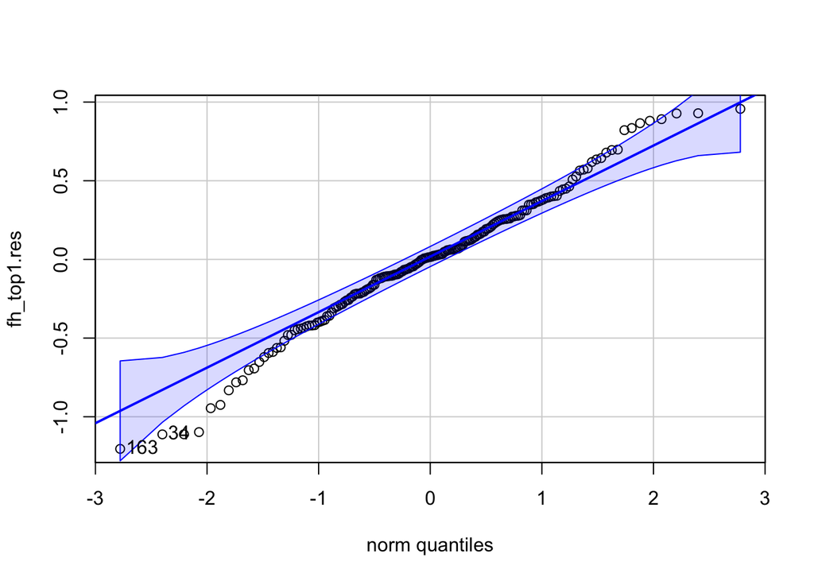

```
## 163  34
## 150  21
```

```r
# lmer removes NAs but our linear model in the ANOVA, so we'll have to remove the NA's
scaled.flamm.df.noNAs <- scaled.flamm.df %>%
  select(fh, species, lfm, mpa, ww_flam_sample, dw_flam_sample, sample_wt, branch_volume, LMA, branching, plant_id) %>%
  na.omit() # this removed 13 samples

# Model
fh_top1 <- lmer(fh ~ mpa + sample_wt + LMA + branching + (1|plant_id), data = scaled.flamm.df.noNAs, REML = F)

#Checking Assumptions
#Assumption 1: Observed y are independent, randomly sampled
#Assumption 2: Residuals are normally distributed - use qqplot
fh_top1.res <- residuals(fh_top1)
qqPlot(fh_top1.res) #From package CAR, looks good to me
```

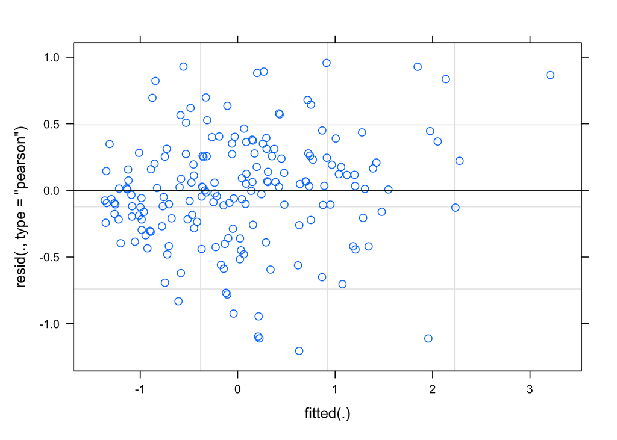

```r
#Assumptions 3 and 4: Residuals have constant variance; and there is a straight line relationship between y and x and random effects (z) - use residuals vs. fitted plot
plot(fh_top1)
```

```r
#Assumption 5: Random effects are independent of y - random sampling
#Assumption 6: Random effects are normally distributed - tough to check

#Test effects of fixed effect with ANOVA
fh_top1.0 <- lmer(fh ~ (1|plant_id), data = scaled.flamm.df.noNAs, REML = F)
anova(fh_top1, fh_top1.0) #P-value shows that fixed effects have significant effect on the y
```

```
## Data: scaled.flamm.df.noNAs
## Models:
## fh_top1.0: fh ~ (1 | plant_id)
## fh_top1: fh ~ mpa + sample_wt + LMA + branching + (1 | plant_id)
##           npar    AIC    BIC  logLik deviance  Chisq Df Pr(>Chisq)
## fh_top1.0    3 429.47 439.10 -211.74   423.47
## fh_top1      7 349.87 372.33 -167.93   335.87 87.608  4  < 2.2e-16 ***
## ---
## Signif. codes:  0 '***' 0.001 '**' 0.01 '*' 0.05 '.' 0.1 ' ' 1
```

```r
#Test effects of random effect with parametric bootstrap method
nBoot=1000
lrStat=rep(NA,nBoot)
fh_null <- lm(fh ~ mpa + sample_wt + LMA + branching, data = scaled.flamm.df.noNAs) # null model
fh_alt <- lmer(fh ~ mpa + sample_wt + LMA + branching + (1|plant_id), data = scaled.flamm.df.noNAs, REML = F) # alternate model
lrObs <- 2*logLik(fh_alt) - 2*logLik(fh_null) # observed test stat
for(iBoot in 1:nBoot)
{
  scaled.flamm.df.noNAs$fhSim=unlist(simulate(fh_null)) #resampled data
  bNull <- lm(fh ~ ww_flam_sample + LMA + branching, data = scaled.flamm.df.noNAs) # null model
  bAlt <- lmer(fh ~ ww_flam_sample + LMA + branching + (1|plant_id), data = scaled.flamm.df.noNAs, REML = F) # alternate model
  lrStat[iBoot] <- 2*logLik(bAlt) - 2*logLik(bNull) # resampled test stat
}
mean(lrStat>lrObs) #P-value for test of plant_id effect
```

```
## [1] 0
```

## Alternative Process (Note)

There are other functions that try and get the ‘best’ model for the data by comparing p-values and discarding multicollinear variables and such; however, in my experience, these functions are flawed, as (1) they often do not select the ‘best’ model, (2) the user cannot see the processes driving the model selection and cannot tweak the model selection according to their questions or the EDA, and (3) it does not take into account multicollinearity

```r
# step() is very sensitive to NAs, so we'll have to remove the NA's
scaled.flamm.df.noNAs <- scaled.flamm.df %>%
  select(fh, species, lfm, mpa, ww_flam_sample, dw_flam_sample, sample_wt, branch_volume, LMA, branching, plant_id) %>%
  na.omit() # this removed 13 samples

# For the first example, let's throw the kitchen sink at this function and see what it spits out
fh_step <- lmer(fh ~ species + lfm + mpa + ww_flam_sample + dw_flam_sample + sample_wt + branch_volume + LMA + branching + (1|plant_id), data = scaled.flamm.df.noNAs)
```

```
## fixed-effect model matrix is rank deficient so dropping 1 column / coefficient
```

```r
# Stepwise model selection
step_res <- step(fh_step, ddf = 'Kenward-Roger')
```

```
## fixed-effect model matrix is rank deficient so dropping 1 column / coefficient
## fixed-effect model matrix is rank deficient so dropping 1 column / coefficient
## fixed-effect model matrix is rank deficient so dropping 1 column / coefficient
## fixed-effect model matrix is rank deficient so dropping 1 column / coefficient
```

```r
final <- get_model(step_res)
# Checking out selected model
summary(final)
```

```
## Linear mixed model fit by REML. t-tests use Satterthwaite's method [
## lmerModLmerTest]
## Formula: fh ~ species + ww_flam_sample + dw_flam_sample + sample_wt +
##     branching + (1 | plant_id)
##    Data: scaled.flamm.df.noNAs
##
## REML criterion at convergence: 337.3
##
## Scaled residuals:
##      Min       1Q   Median       3Q      Max
## -2.47966 -0.42978 -0.01361  0.44152  2.48314
##
## Random effects:
##  Groups   Name        Variance Std.Dev.
##  plant_id (Intercept) 0.2559   0.5059
##  Residual             0.2307   0.4803
## Number of obs: 183, groups:  plant_id, 59
##
## Fixed effects:
##                 Estimate Std. Error        df t value Pr(>|t|)
## (Intercept)      0.57256    0.24048  34.13913   2.381 0.022991 *
## speciesERIKAR   -1.13590    0.31750  37.74447  -3.578 0.000972 ***
## speciesHETARB    0.40649    0.49597  70.05321   0.820 0.415231
## speciesIRIDOU   -0.79970    0.34102  40.28849  -2.345 0.024039 *
## speciesMALLAU   -0.55056    0.34776  47.05066  -1.583 0.120083
## speciesMANDEN   -0.33967    0.40496  42.54418  -0.839 0.406284
## speciesSALAPI   -0.32760    0.38411  49.76348  -0.853 0.397805
## speciesSALLEU   -0.52041    0.31229  28.65740  -1.666 0.106528
## ww_flam_sample   0.78195    0.35702  88.44007   2.190 0.031139 *
## dw_flam_sample  -0.34092    0.36799  89.63956  -0.926 0.356710
## branching        0.19267    0.06731 152.26152   2.863 0.004794 **
## ---
## Signif. codes:  0 '***' 0.001 '**' 0.01 '*' 0.05 '.' 0.1 ' ' 1
##
## Correlation of Fixed Effects:
##             (Intr) sERIKA sHETAR sIRIDO sMALLA sMANDE sSALAP sSALLE ww_fl_
## specsERIKAR -0.778
## specsHETARB -0.493  0.325
## specsIRIDOU -0.742  0.608  0.345
## specsMALLAU -0.721  0.494  0.530  0.497
## specsMANDEN -0.585  0.465  0.211  0.436  0.389
## specsSALAPI -0.719  0.542  0.192  0.527  0.567  0.443
## specsSALLEU -0.717  0.560  0.385  0.527  0.493  0.417  0.435
## ww_flm_smpl  0.103 -0.067  0.446 -0.058 -0.069 -0.140 -0.526  0.060
## dw_flm_smpl -0.082  0.089 -0.541  0.064 -0.034  0.144  0.471 -0.057 -0.975
## branching   -0.303  0.273  0.455  0.316  0.350  0.108  0.268  0.132  0.152
##             dw_fl_
## specsERIKAR
## specsHETARB
## specsIRIDOU
## specsMALLAU
## specsMANDEN
## specsSALAPI
## specsSALLEU
## ww_flm_smpl
## dw_flm_smpl
## branching   -0.231
## fit warnings:
## fixed-effect model matrix is rank deficient so dropping 1 column / coefficient
```

```r
multicollinearity(final) # step() does not take into account multicollinearity, so the 'final' model is invalid in this example
```

[output not shown]

```r
# For the second example, let's throw the identified 'best' predictors and species and see what it says
fh_step2 <- lmer(fh ~ species + mpa + sample_wt + LMA + branching + (1|plant_id), data = scaled.flamm.df.noNAs)
# Stepwise model selection
step_res <- step(fh_step2, ddf = 'Kenward-Roger')
final <- get_model(step_res)
# Checking out selected model
summary(final)
```

```
## Linear mixed model fit by REML. t-tests use Satterthwaite's method [
## lmerModLmerTest]
## Formula: fh ~ species + sample_wt + branching + (1 | plant_id)
##    Data: scaled.flamm.df.noNAs
##
## REML criterion at convergence: 338.8
##
## Scaled residuals:
##     Min      1Q  Median      3Q     Max
## -2.5182 -0.4230 -0.0103  0.4406  2.4990
##
## Random effects:
##  Groups   Name        Variance Std.Dev.
##  plant_id (Intercept) 0.2458   0.4958
##  Residual             0.2343   0.4840
## Number of obs: 183, groups:  plant_id, 59
##
## Fixed effects:
##                Estimate Std. Error        df t value Pr(>|t|)
## (Intercept)     0.54427    0.23638  35.32936   2.302  0.02731 *
## speciesERIKAR  -1.09997    0.31254  39.14862  -3.519  0.00111 **
## speciesHETARB   0.07064    0.42147  66.97458   0.168  0.86740
## speciesIRIDOU  -0.77011    0.33641  41.89379  -2.289  0.02718 *
## speciesMALLAU  -0.55606    0.34418  48.79664  -1.616  0.11263
## speciesMANDEN  -0.26610    0.39625  43.42196  -0.672  0.50542
## speciesSALAPI  -0.08484    0.33148  47.98999  -0.256  0.79909
## speciesSALLEU  -0.54352    0.30713  29.40279  -1.770  0.08716 .
## sample_wt       0.45829    0.08042 154.77662   5.699 5.93e-08 ***
## branching       0.17476    0.06613 151.26825   2.643  0.00909 **
## ---
## Signif. codes:  0 '***' 0.001 '**' 0.01 '*' 0.05 '.' 0.1 ' ' 1
##
## Correlation of Fixed Effects:
##             (Intr) sERIKA sHETAR sIRIDO sMALLA sMANDE sSALAP sSALLE smpl_w
## specsERIKAR -0.777
## specsHETARB -0.631  0.430
## specsIRIDOU -0.741  0.608  0.440
## specsMALLAU -0.723  0.493  0.616  0.497
## specsMANDEN -0.579  0.458  0.334  0.432  0.391
## specsSALAPI -0.777  0.577  0.595  0.570  0.652  0.430
## specsSALLEU -0.726  0.568  0.414  0.532  0.491  0.429  0.532
## sample_wt    0.098  0.095 -0.468  0.023 -0.462  0.013 -0.307  0.015
## branching   -0.336  0.304  0.418  0.343  0.360  0.145  0.441  0.126 -0.346
```

```r
multicollinearity(final)
```

```
## # Check for Multicollinearity
##
## Low Correlation
##
##       Term  VIF   VIF 95% CI Increased SE Tolerance Tolerance 95% CI
##    species 2.67 [2.18, 3.37]         1.63      0.37     [0.30, 0.46]
##  sample_wt 2.17 [1.79, 2.72]         1.47      0.46     [0.37, 0.56]
##  branching 1.47 [1.27, 1.82]         1.21      0.68     [0.55, 0.79]
```

```r
# Comparing to top model selected above:
fh_step_selected <- lmer(fh ~ species + sample_wt + branching + (1|plant_id), data = scaled.flamm.df)
# Using full dataset now
AIC(fh_step_selected)
```

```
## [1] 387.9107
```

```r
AIC(fh_top1)
```

```
## [1] 349.8655
```

```r
# The step-selected is significantly worse; now, maybe this is because of the NAs reintroduced into the data, so this may not be a totally fair comparison.
```

## Visualizations via REMEF

### MPa vs. FH

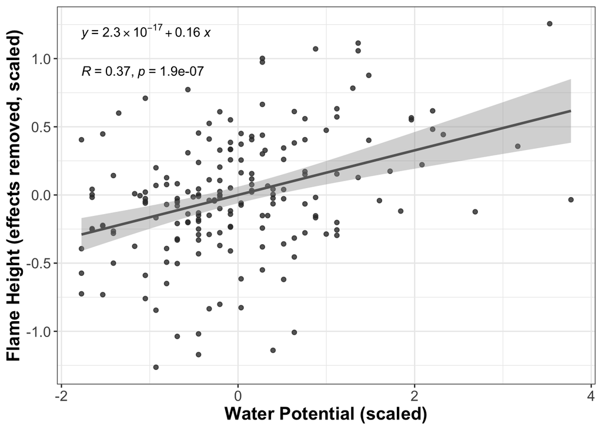

```r
fh_top1 <- lmer(fh ~ mpa + sample_wt + LMA + branching + (1|plant_id), data = scaled.flamm.df.noNAs, REML = F) # remef is also sensitive to NAs

scaled.flamm.df.noNAs$r_fh <- remef(fh_top1, fix = c('LMA', 'branching', 'sample_wt'), ran = "all", keep.intercept = FALSE) # w/ remef, we are removing the fixed effects of LMA, sample weight and branching and removing the random effects to isolate the relationship between mpa and flame height

# With REMEF
ggplot(scaled.flamm.df.noNAs, aes(x = mpa, y = r_fh))  +
  geom_point(alpha = 0.8, color = 'gray20') +
  geom_smooth(method = 'lm', color = 'gray40') +
  stat_cor(label.y = 0.9)+
  stat_regline_equation(label.y = 1.2) +
  labs(x = 'Water Potential (scaled)', y = 'Flame Height (effects removed, scaled)') +
  theme_bw() +
  theme(axis.title = element_text(face = 'bold', size = 15),
        axis.text = element_text(size = 12))
```

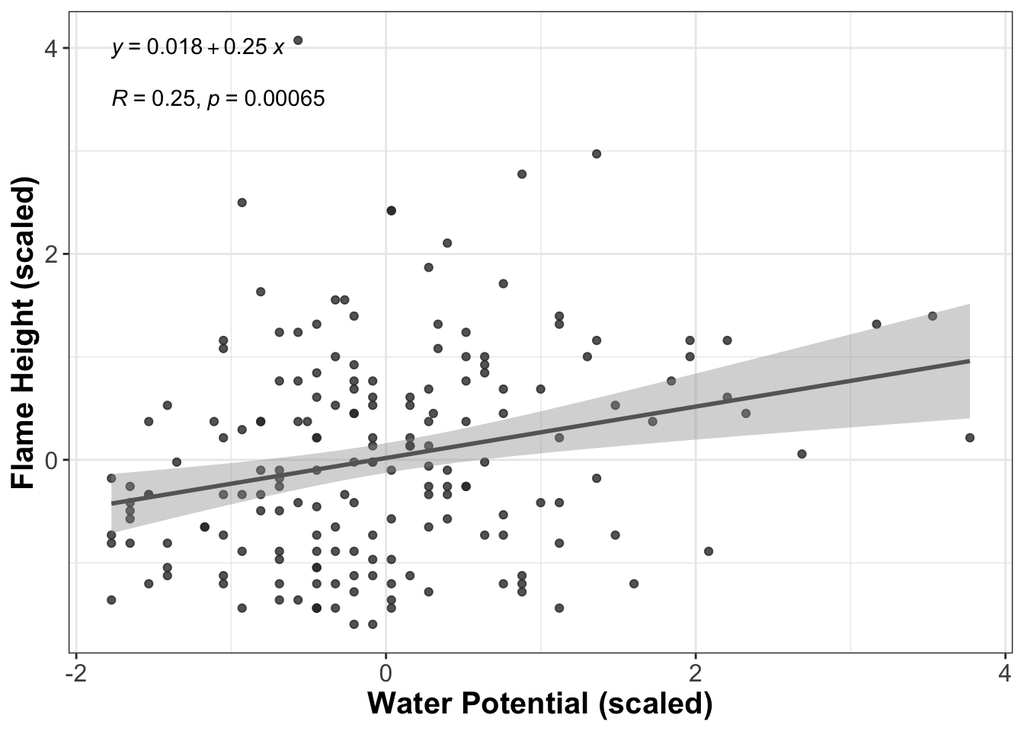

```r
# Without REMEF
ggplot(scaled.flamm.df.noNAs, aes(x = mpa, y = fh))  +
  geom_point(alpha = 0.8, color = 'gray20') +
  geom_smooth(method = 'lm', color = 'gray40') +
  stat_cor(label.y = 3.5)+
  stat_regline_equation(label.y = 4) +
  labs(x = 'Water Potential (scaled)', y = 'Flame Height (scaled)') +
  theme_bw() +
  theme(axis.title = element_text(face = 'bold', size = 15),
        axis.text = element_text(size = 12))
```

### Sample Wt. vs. FH

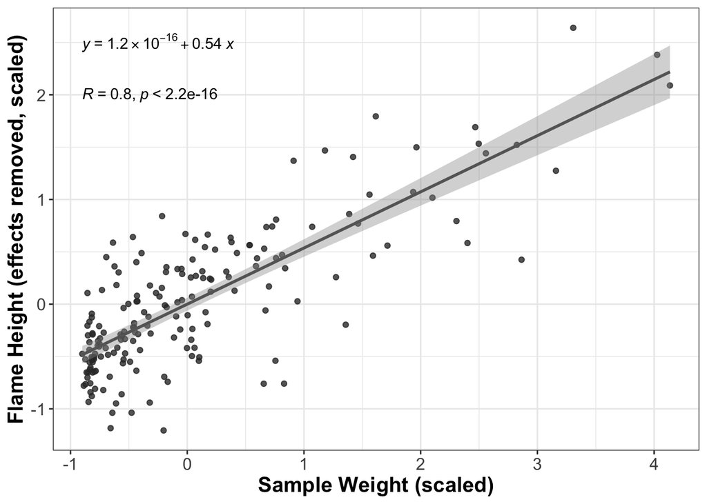

```r
scaled.flamm.df.noNAs$r_fh2 <- remef(fh_top1, fix = c('LMA', 'branching', 'mpa'), ran = "all", keep.intercept = FALSE) # w/ remef, we are removing the fixed effects of LMA, mpa and branching and removing the random effects to isolate the relationship between sample weight and flame height

# With REMEF
ggplot(scaled.flamm.df.noNAs, aes(x = sample_wt, y = r_fh2))  +
  geom_point(alpha = 0.8, color = 'gray20') +
  geom_smooth(method = 'lm', color = 'gray40') +
  stat_cor(label.y = 2)+
  stat_regline_equation(label.y = 2.5) +
  labs(x = 'Sample Weight (scaled)', y = 'Flame Height (effects removed, scaled)') +
  theme_bw() +
  theme(axis.title = element_text(face = 'bold', size = 15),
        axis.text = element_text(size = 12))
```

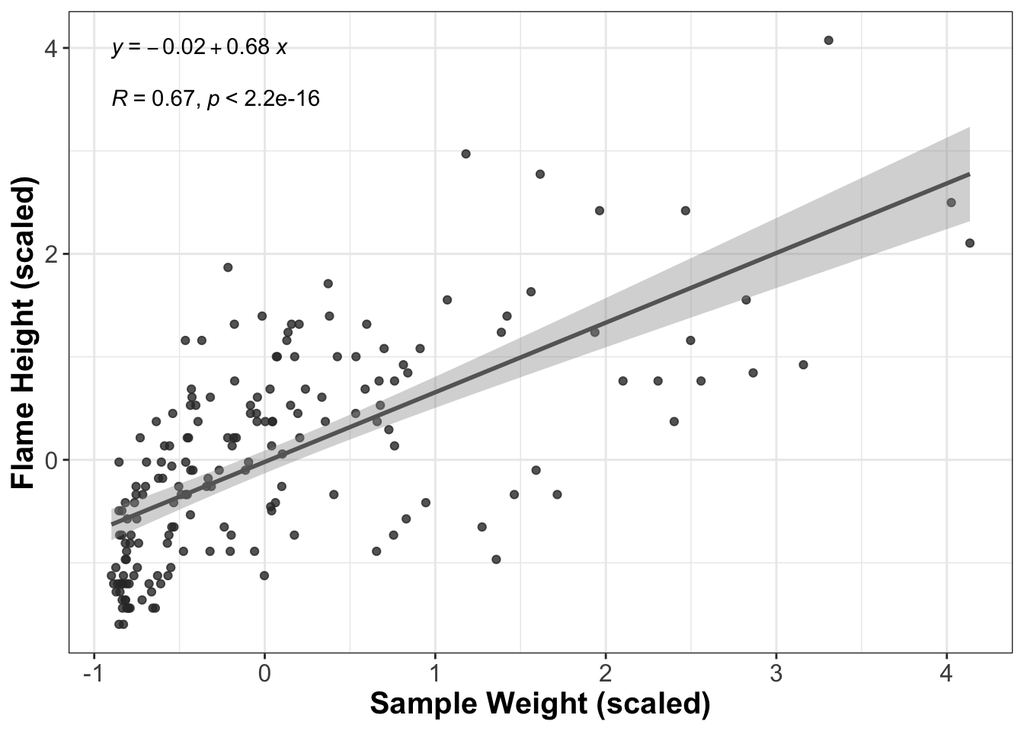

```r
# Without REMEF
ggplot(scaled.flamm.df.noNAs, aes(x = sample_wt, y = fh))  +
  geom_point(alpha = 0.8, color = 'gray20') +
  geom_smooth(method = 'lm', color = 'gray40') +
  stat_cor(label.y = 3.5)+
  stat_regline_equation(label.y = 4) +
  labs(x = 'Sample Weight (scaled)', y = 'Flame Height (scaled)') +
  theme_bw() +
  theme(axis.title = element_text(face = 'bold', size = 15),
        axis.text = element_text(size = 12))
```